# Investigating the GDP, child mortality rate, and female education around the globe using the Gapminder datasets.

- Introduction
- Data Wrangling
- Exploratory Data Analysis
- Conclusions

## Introduction

For this project, we've been asked to perform exploratory data analysis using NumPy and Pandas and to use data visualization as a means to display some possible relationships within the datasets. These are only qualitative findings as they are not supported with any inferential statitics but they provide an important first glance into the datasets and may provide strong foundation for future exploration and hypothesis testing.

I chose to explore the Gapminder datasets. I chose three indicator datasets which I explore below. These are:

1. Child mortality rate (child mortality of ages 0-5 dying per 1000 born)
2. GDP per capita (Income per person adjusted for inflation)
3. Education of women (average number of years of schooling women have had by the age range 35-44 years)

I chose these datasets because I wanted to explore questions relating to the education rate of women around the world and how it relates to infant and child health and GDP? I chose the age range of 35-44 years because by the age of 35 most women around the world have already had at least 1 baby if not have at least 1 child who has already reached the age of 5.

I will explore three primary questions. These are:

1. Which countries are in the low range, which countries are in the high range?

   > Which countries have highest GDP, lowest GDP?  
   > Which coutries have most educated women, least educated women?  
   > Which countries have highest child mortality, lowest child mortality?
2. Where have there been increases, where have these indicators been stagnant?

   > Where has GDP increased the most since 1970? Where has GDP growth been stagnant?  
   > Where has child mortality decreased the most since 1970? Where has child mortality been stagnant?  
   > Where has education rate of women increased the most since 1970? Where has it been stagnant?
3. What is the child mortality rate like in countries with highly educated women compared to those with uneducated women?

   > Do wealthier countries have more highly educated women?  
   > Do wealthier countries have lower child mortality?  
   > Do highly educated women have healthier babies/children?

Importantly, these data may have been updated by other sources but for consistency I chose a terminal year of 2015 for all datasets to make sure comparisons are comparable.

## Data Wrangling

### General Properties

```python
import pandas as pd
import matplotlib.pyplot as plt
%matplotlib inline

pd.options.display.max_rows = 4000
```

```python
# Load data and print out a few lines. Perform operations to inspect data
school = pd.read_csv('mean_years_in_school_women_35_to_44_years.csv')
M = pd.read_csv('child_mortality_0_5_year_olds_dying_per_1000_born.csv')
inc = pd.read_csv('income_per_person_gdppercapita_ppp_inflation_adjusted.csv')
```

```python
school.head(5)
```

|  | country | 1970 | 1971 | 1972 | 1973 | 1974 | 1975 | 1976 | 1977 | 1978 | 1979 | 1980 | 1981 | 1982 | 1983 | 1984 | 1985 | 1986 | 1987 | 1988 | 1989 | 1990 | 1991 | 1992 | 1993 | 1994 | 1995 | 1996 | 1997 | … |
| --- | --- | --- | --- | --- | --- | --- | --- | --- | --- | --- | --- | --- | --- | --- | --- | --- | --- | --- | --- | --- | --- | --- | --- | --- | --- | --- | --- | --- | --- | --- |
| 0 | Afghanistan | 0.15 | 0.16 | 0.16 | 0.17 | 0.18 | 0.18 | 0.19 | 0.20 | 0.20 | 0.21 | 0.22 | 0.22 | 0.23 | 0.24 | 0.25 | 0.26 | 0.27 | 0.28 | 0.29 | 0.30 | 0.31 | 0.32 | 0.33 | 0.34 | 0.35 | 0.37 | 0.38 | 0.40 | … |
| 1 | Albania | 5.04 | 5.16 | 5.29 | 5.43 | 5.56 | 5.70 | 5.83 | 5.97 | 6.12 | 6.26 | 6.40 | 6.55 | 6.70 | 6.85 | 7.00 | 7.15 | 7.30 | 7.46 | 7.61 | 7.77 | 7.93 | 8.09 | 8.25 | 8.41 | 8.57 | 8.73 | 8.89 | 9.05 | … |
| 2 | Algeria | 1.01 | 1.05 | 1.08 | 1.12 | 1.16 | 1.20 | 1.24 | 1.29 | 1.33 | 1.38 | 1.43 | 1.48 | 1.53 | 1.58 | 1.64 | 1.70 | 1.76 | 1.82 | 1.88 | 1.95 | 2.02 | 2.09 | 2.16 | 2.24 | 2.32 | 2.41 | 2.48 | 2.56 | … |
| 3 | Andorra | 6.68 | 6.83 | 6.98 | 7.14 | 7.29 | 7.45 | 7.61 | 7.77 | 7.93 | 8.09 | 8.26 | 8.42 | 8.59 | 8.75 | 8.92 | 9.09 | 9.26 | 9.43 | 9.59 | 9.76 | 9.93 | 10.10 | 10.30 | 10.40 | 10.60 | 10.80 | 10.90 | 11.10 | … |
| 4 | Angola | 1.12 | 1.16 | 1.20 | 1.24 | 1.28 | 1.32 | 1.36 | 1.41 | 1.45 | 1.50 | 1.55 | 1.60 | 1.65 | 1.71 | 1.76 | 1.82 | 1.88 | 1.94 | 2.00 | 2.07 | 2.13 | 2.20 | 2.27 | 2.34 | 2.42 | 2.50 | 2.58 | 2.66 | … |

```python
M.head(5)
```

|  | country | 1800 | 1801 | 1802 | 1803 | 1804 | 1805 | 1806 | 1807 | 1808 | 1809 | 1810 | 1811 | 1812 | 1813 | 1814 | 1815 | 1816 | 1817 | 1818 | 1819 | 1820 | 1821 | 1822 | 1823 | 1824 | 1825 | 1826 | 1827 | … |
| --- | --- | --- | --- | --- | --- | --- | --- | --- | --- | --- | --- | --- | --- | --- | --- | --- | --- | --- | --- | --- | --- | --- | --- | --- | --- | --- | --- | --- | --- | --- |
| 0 | Afghanistan | 469.0 | 469.0 | 469.0 | 469.0 | 469.0 | 469.0 | 470.0 | 470.0 | 470.0 | 470.0 | 470.0 | 470.0 | 470.0 | 470.0 | 470.0 | 470.0 | 471.0 | 471.0 | 471.0 | 471.0 | 471.0 | 471.0 | 471.0 | 471.0 | 471.0 | 471.0 | 473.0 | 473.0 | … |
| 1 | Albania | 375.0 | 375.0 | 375.0 | 375.0 | 375.0 | 375.0 | 375.0 | 375.0 | 375.0 | 375.0 | 375.0 | 375.0 | 375.0 | 375.0 | 375.0 | 375.0 | 375.0 | 375.0 | 375.0 | 375.0 | 375.0 | 375.0 | 375.0 | 375.0 | 375.0 | 375.0 | 375.0 | 375.0 | … |
| 2 | Algeria | 460.0 | 460.0 | 460.0 | 460.0 | 460.0 | 460.0 | 460.0 | 460.0 | 460.0 | 460.0 | 460.0 | 460.0 | 460.0 | 460.0 | 460.0 | 460.0 | 460.0 | 460.0 | 460.0 | 460.0 | 460.0 | 460.0 | 460.0 | 460.0 | 460.0 | 460.0 | 460.0 | 460.0 | … |
| 3 | Andorra | NaN | NaN | NaN | NaN | NaN | NaN | NaN | NaN | NaN | NaN | NaN | NaN | NaN | NaN | NaN | NaN | NaN | NaN | NaN | NaN | NaN | NaN | NaN | NaN | NaN | NaN | NaN | NaN | … |
| 4 | Angola | 486.0 | 486.0 | 486.0 | 486.0 | 486.0 | 486.0 | 486.0 | 486.0 | 486.0 | 486.0 | 486.0 | 486.0 | 486.0 | 486.0 | 486.0 | 486.0 | 486.0 | 486.0 | 486.0 | 486.0 | 486.0 | 486.0 | 486.0 | 486.0 | 486.0 | 486.0 | 486.0 | 486.0 | … |

```python
inc.head(5)
```

|  | country | 1800 | 1801 | 1802 | 1803 | 1804 | 1805 | 1806 | 1807 | 1808 | 1809 | 1810 | 1811 | 1812 | 1813 | 1814 | 1815 | 1816 | 1817 | 1818 | 1819 | 1820 | 1821 | 1822 | 1823 | 1824 | 1825 | 1826 | 1827 | … |
| --- | --- | --- | --- | --- | --- | --- | --- | --- | --- | --- | --- | --- | --- | --- | --- | --- | --- | --- | --- | --- | --- | --- | --- | --- | --- | --- | --- | --- | --- | --- |
| 0 | Afghanistan | 603 | 603 | 603 | 603 | 603 | 603 | 603 | 603 | 603 | 603 | 604 | 604 | 604 | 604 | 604 | 604 | 604 | 604 | 604 | 604 | 604 | 607 | 609 | 611 | 613 | 615 | 617 | 619 | … |
| 1 | Albania | 667 | 667 | 667 | 667 | 667 | 668 | 668 | 668 | 668 | 668 | 668 | 668 | 668 | 668 | 668 | 669 | 669 | 669 | 669 | 669 | 669 | 671 | 672 | 674 | 675 | 677 | 678 | 680 | … |
| 2 | Algeria | 715 | 716 | 717 | 718 | 719 | 720 | 721 | 722 | 723 | 724 | 725 | 726 | 727 | 728 | 729 | 730 | 731 | 732 | 733 | 734 | 735 | 743 | 751 | 759 | 767 | 775 | 784 | 792 | … |
| 3 | Andorra | 1200 | 1200 | 1200 | 1200 | 1210 | 1210 | 1210 | 1210 | 1220 | 1220 | 1220 | 1220 | 1220 | 1230 | 1230 | 1230 | 1230 | 1240 | 1240 | 1240 | 1240 | 1260 | 1270 | 1290 | 1300 | 1320 | 1330 | 1350 | … |
| 4 | Angola | 618 | 620 | 623 | 626 | 628 | 631 | 634 | 637 | 640 | 642 | 645 | 648 | 651 | 654 | 657 | 660 | 662 | 665 | 668 | 671 | 674 | 677 | 680 | 683 | 686 | 689 | 692 | 695 | … |

**What are the dimensions of each?**

```python
school.shape
```

```
(187, 47)
```

```python
M.shape
```

```
(193, 220)
```

```python
inc.shape
```

```
(193, 242)
```

**Looks like there are some inconsistences in total years (columns) in each dataset as well as the the countries (rows). Now check to see if there are any missing values?** https://stackoverflow.com/questions/43427564/display-all-informations-with-data-info-in-python

```python
school.info()
```

```
<class 'pandas.core.frame.DataFrame'>
RangeIndex: 187 entries, 0 to 186
Data columns (total 47 columns):
country    187 non-null object
1970       187 non-null float64
1971       187 non-null float64
1972       187 non-null float64
1973       187 non-null float64
1974       187 non-null float64
1975       187 non-null float64
1976       187 non-null float64
1977       187 non-null float64
1978       187 non-null float64
1979       187 non-null float64
1980       187 non-null float64
```

[output cut: 37 more lines]

```python
M.info(verbose=True, null_counts=True)
```

```
<class 'pandas.core.frame.DataFrame'>
RangeIndex: 193 entries, 0 to 192
Data columns (total 220 columns):
country    193 non-null object
1800       184 non-null float64
1801       184 non-null float64
1802       184 non-null float64
1803       184 non-null float64
1804       184 non-null float64
1805       184 non-null float64
1806       184 non-null float64
1807       184 non-null float64
1808       184 non-null float64
1809       184 non-null float64
1810       184 non-null float64
```

[output cut: 210 more lines]

```python
inc.info(verbose=True, null_counts=True)
```

```
<class 'pandas.core.frame.DataFrame'>
RangeIndex: 193 entries, 0 to 192
Data columns (total 242 columns):
country    193 non-null object
1800       193 non-null int64
1801       193 non-null int64
1802       193 non-null int64
1803       193 non-null int64
1804       193 non-null int64
1805       193 non-null int64
1806       193 non-null int64
1807       193 non-null int64
1808       193 non-null int64
1809       193 non-null int64
1810       193 non-null int64
```

[output cut: 232 more lines]

**Looks like there are also some missing values. Let's check to make sure the datatype are ok.**

```python
inc.dtypes
```

```
country    object
1800       int64
1801       int64
1802       int64
1803       int64
1804       int64
1805       int64
1806       int64
1807       int64
1808       int64
1809       int64
1810       int64
1811       int64
1812       int64
1813       int64
```

[output cut: 228 more lines]

```python
M.dtypes
```

```
country    object
1800       float64
1801       float64
1802       float64
1803       float64
1804       float64
1805       float64
1806       float64
1807       float64
1808       float64
1809       float64
1810       float64
1811       float64
1812       float64
1813       float64
```

[output cut: 206 more lines]

```python
school.dtypes
```

```
country    object
1970       float64
1971       float64
1972       float64
1973       float64
1974       float64
1975       float64
1976       float64
1977       float64
1978       float64
1979       float64
1980       float64
1981       float64
1982       float64
1983       float64
```

[output cut: 33 more lines]

**These datatypes are ok by my standards. Ints and floats, while not the same, are fine for data visualization.**

**Last, let's check to make sure there are no duplicated countries in each dataset**

```python
M.duplicated('country').sum()
```

```
0
```

```python
school.duplicated('country').sum()
```

```
0
```

```python
inc.duplicated('country').sum()
```

```
0
```

**Ok. No duplicated country names. That's good. We can now data clean.**

### Data Cleaning

Here the data need to be cleaned and wrangled.

1. Make sure countries are consistent with each other.
2. The years need to be made consistent.
3. Any missing values need to be imputed.

**1. Make sure the datsets contain the same countries**

```python
school['country'].nunique()
```

```
187
```

```python
M['country'].nunique()
```

```
193
```

```python
inc['country'].nunique()
```

```
193
```

**Looks like there's some inconsistencies**  
Filter out the countries from `M` and `inc` that are not in the `school` df.

Use these resources:

> https://stackoverflow.com/questions/38516664/anti-join-pandas  
> https://stackoverflow.com/questions/12065885/filter-dataframe-rows-if-value-in-column-is-in-a-set-list-of-values

```python
#these are the countries in the M df that are not in the school df
m1 = set(M.country).difference(school.country)
m1
```

```
{'Monaco', 'Nauru', 'Palau', 'San Marino', 'St. Kitts and Nevis', 'Tuvalu'}
```

Check to make sure that the difference between `M` and `school` (as shown above) is the same thing as between `inc` and `school`.

```python
m2 = set(inc.country).difference(school.country)
m1 == m2
```

```
True
```

Both `M` and `inc` have the same extra countries. So just use the countries in `school` to filter countries in `M` and `inc`.

```python
inc = inc[inc['country'].isin(school['country'])]
```

```python
M = M[M['country'].isin(school['country'])]
```

```python
inc.shape
```

```
(187, 242)
```

```python
M.shape
```

```
(187, 220)
```

**2. Now, make sure the years are the same among all datasets.** I'll select from 1970 to 2015 because all of those years are in all three datasets. I will only need to filter `inc` and `M`. To do this I will use the columns that are in school as a filter for columns in `M` and `inc`

```python
M = M.loc[:,list(school.columns)]
inc = inc.loc[:,list(school.columns)]
```

```python
M.columns
```

```
Index(['country', '1970', '1971', '1972', '1973', '1974', '1975', '1976',
       '1977', '1978', '1979', '1980', '1981', '1982', '1983', '1984', '1985',
       '1986', '1987', '1988', '1989', '1990', '1991', '1992', '1993', '1994',
       '1995', '1996', '1997', '1998', '1999', '2000', '2001', '2002', '2003',
       '2004', '2005', '2006', '2007', '2008', '2009', '2010', '2011', '2012',
       '2013', '2014', '2015'],
      dtype='object')
```

```python
inc.columns
```

```
Index(['country', '1970', '1971', '1972', '1973', '1974', '1975', '1976',
       '1977', '1978', '1979', '1980', '1981', '1982', '1983', '1984', '1985',
       '1986', '1987', '1988', '1989', '1990', '1991', '1992', '1993', '1994',
       '1995', '1996', '1997', '1998', '1999', '2000', '2001', '2002', '2003',
       '2004', '2005', '2006', '2007', '2008', '2009', '2010', '2011', '2012',
       '2013', '2014', '2015'],
      dtype='object')
```

**3.Now let's check on any null values.**

```python
inc.isnull().any(axis=1).sum()
```

```
0
```

```python
school.isnull().any(axis=1).sum()
```

```
0
```

```python
M.isnull().any(axis=1).sum()
```

```
1
```

**One row in M has null values. There are two options to deal with this**

> 1.Remove the row completely and then remove that country from inc and school  
> 2.Fill in the missing values using some method depending on where they are in the dataset.

Let's try option 2 first.

```python
M[M.isnull().any(axis=1)]
```

|  | country | 1970 | 1971 | 1972 | 1973 | 1974 | 1975 | 1976 | 1977 | 1978 | 1979 | 1980 | 1981 | 1982 | 1983 | 1984 | 1985 | 1986 | 1987 | 1988 | 1989 | 1990 | 1991 | 1992 | 1993 | 1994 | 1995 | 1996 | 1997 | … |
| --- | --- | --- | --- | --- | --- | --- | --- | --- | --- | --- | --- | --- | --- | --- | --- | --- | --- | --- | --- | --- | --- | --- | --- | --- | --- | --- | --- | --- | --- | --- |
| 3 | Andorra | NaN | NaN | NaN | NaN | NaN | NaN | NaN | NaN | NaN | NaN | NaN | NaN | NaN | NaN | NaN | 12.9 | 11.9 | 11.1 | 10.2 | 9.5 | 8.8 | 8.1 | 7.5 | 7.0 | 6.5 | 6.1 | 5.7 | 5.3 | … |

Ok. It looks like it's the beginning of the dataset. So I will fill these values in with the mean values for years 1985,1986,1987.  
I used this resource: https://stackoverflow.com/questions/34913590/fillna-in-multiple-columns-in-place-in-python-pandas

```python
mean = M[M.isnull().any(axis=1)].loc[:,['1985', '1986', '1987']].mean(axis=1)

new_and = M[M['country'] == 'Andorra'].apply(lambda x: x.fillna(mean))
M[M['country'] == "Andorra"] = new_and
```

Ok, let's check to make sure it worked. Now there should be no missing values in M...

```python
M.isnull().any(axis=1).sum()
```

```
0
```

Andorra should have filled in values...

```python
M[M['country'] == "Andorra"]
```

|  | country | 1970 | 1971 | 1972 | 1973 | 1974 | 1975 | 1976 | 1977 | 1978 | 1979 | 1980 | 1981 | 1982 | 1983 | 1984 | 1985 | 1986 | 1987 | 1988 | 1989 | 1990 | 1991 | 1992 | 1993 | 1994 | 1995 | 1996 | 1997 | … |
| --- | --- | --- | --- | --- | --- | --- | --- | --- | --- | --- | --- | --- | --- | --- | --- | --- | --- | --- | --- | --- | --- | --- | --- | --- | --- | --- | --- | --- | --- | --- |
| 3 | Andorra | 11.966667 | 11.966667 | 11.966667 | 11.966667 | 11.966667 | 11.966667 | 11.966667 | 11.966667 | 11.966667 | 11.966667 | 11.966667 | 11.966667 | 11.966667 | 11.966667 | 11.966667 | 12.9 | 11.9 | 11.1 | 10.2 | 9.5 | 8.8 | 8.1 | 7.5 | 7.0 | 6.5 | 6.1 | 5.7 | 5.3 | … |

## Exploratory Data Analysis

We are now ready to explore the datasets.

### Research Question 1: Which countries are in the low range, which countries are in the high range?

> A. In 2015, which countries have highest GDP, lowest GDP?  
> B. In 2015, which countries have highest child mortality, lowest child mortality?  
> C. In 2015, which coutries have most educated women, least educated women?

**A. Which countriest have highest and lowest GDP PPP**

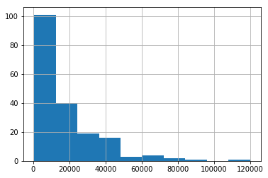

```python
#first visualize the overal GDP in PPP for 2015
inc['2015'].hist();
#looks like it's a very right skewed distribution
```

```python
#first figure out the 5 number summary for 2015 to make some bins
sum = inc['2015'].describe()
sum
```

```
count    187.000000
mean     17178.716578
std      19082.450381
min      623.000000
25%      3270.000000
50%      10800.000000
75%      24100.000000
max      120000.000000
Name: 2015, dtype: float64
```

```python
#make bins
min1 = sum['min']
low = (min1 + sum['25%'])/2
low_med = sum['25%']
med = sum['50%']
med_high = sum['75%']
high = (med_high + sum['max'])/2
highest = sum['max']

bin_edges = [min1-0.001, low, low_med, med, med_high, high, highest]
bin_names = ['lowest', 'low', 'medium_low', 'medium', 'high', 'highest']
```

```python
#add bins to the inc df
inc['levels2015'] = pd.cut(inc['2015'], bin_edges, labels=bin_names)
```

```python
inc['levels2015'].head(5)
```

```
0    lowest
1    medium
2    medium
3    high
4    medium_low
Name: levels2015, dtype: category
Categories (6, object): [lowest < low < medium_low < medium < high < highest]
```

```python
#select lowest countries and select highest countries
inc[inc['levels2015'] == 'lowest']
```

|  | country | 1970 | 1971 | 1972 | 1973 | 1974 | 1975 | 1976 | 1977 | 1978 | 1979 | 1980 | 1981 | 1982 | 1983 | 1984 | 1985 | 1986 | 1987 | 1988 | 1989 | 1990 | 1991 | 1992 | 1993 | 1994 | 1995 | 1996 | 1997 | … |
| --- | --- | --- | --- | --- | --- | --- | --- | --- | --- | --- | --- | --- | --- | --- | --- | --- | --- | --- | --- | --- | --- | --- | --- | --- | --- | --- | --- | --- | --- | --- |
| 0 | Afghanistan | 1180 | 1100 | 1050 | 1150 | 1180 | 1210 | 1240 | 1130 | 1190 | 1170 | 1170 | 1300 | 1410 | 1470 | 1440 | 1400 | 1500 | 1240 | 1120 | 1100 | 1040 | 1030 | 950 | 818 | 732 | 881 | 904 | 930 | … |
| 26 | Burkina Faso | 790 | 810 | 830 | 774 | 747 | 703 | 683 | 714 | 778 | 766 | 759 | 771 | 767 | 738 | 729 | 801 | 900 | 857 | 898 | 858 | 821 | 872 | 851 | 857 | 845 | 869 | 938 | 970 | … |
| 27 | Burundi | 802 | 849 | 773 | 828 | 810 | 802 | 850 | 936 | 905 | 882 | 914 | 974 | 951 | 959 | 937 | 1030 | 1050 | 1070 | 1080 | 1070 | 1090 | 1120 | 1100 | 1020 | 959 | 870 | 790 | 768 | … |
| 32 | Central African Republic | 1350 | 1270 | 1220 | 1240 | 1180 | 1170 | 1190 | 1250 | 1240 | 1130 | 1090 | 1080 | 1070 | 973 | 1010 | 987 | 980 | 931 | 922 | 927 | 932 | 904 | 824 | 804 | 821 | 858 | 804 | 827 | … |
| 37 | Comoros | 1430 | 1460 | 1460 | 1530 | 1530 | 1580 | 1530 | 1530 | 1510 | 1590 | 1640 | 1640 | 1690 | 1720 | 1730 | 1720 | 1710 | 1690 | 1690 | 1630 | 1600 | 1470 | 1550 | 1550 | 1430 | 1440 | 1380 | 1400 | … |
| 38 | Congo, Dem. Rep. | 2110 | 2210 | 2160 | 2270 | 2340 | 2050 | 1850 | 1790 | 1640 | 1590 | 1580 | 1580 | 1530 | 1510 | 1550 | 1510 | 1540 | 1530 | 1490 | 1420 | 1280 | 1130 | 973 | 809 | 750 | 731 | 704 | 648 | … |
| 54 | Eritrea | 1090 | 1110 | 1120 | 1120 | 1090 | 1020 | 999 | 983 | 913 | 994 | 997 | 999 | 981 | 1030 | 970 | 832 | 884 | 975 | 950 | 915 | 908 | 1000 | 1110 | 1270 | 1540 | 1590 | 1720 | 1830 | … |
| 56 | Ethiopia | 778 | 791 | 803 | 798 | 779 | 728 | 716 | 704 | 654 | 712 | 715 | 716 | 703 | 735 | 696 | 597 | 634 | 700 | 681 | 657 | 652 | 584 | 515 | 562 | 560 | 575 | 626 | 626 | … |
| 61 | Gambia | 1480 | 1600 | 1660 | 1680 | 1960 | 1780 | 1920 | 1960 | 1800 | 2030 | 1770 | 1700 | 1860 | 1590 | 1490 | 1320 | 1350 | 1370 | 1460 | 1510 | 1520 | 1510 | 1510 | 1510 | 1480 | 1450 | 1440 | 1470 | … |
| 68 | Guinea | 963 | 975 | 976 | 1000 | 1050 | 1070 | 1160 | 1160 | 1170 | 1150 | 1160 | 1150 | 1140 | 1130 | 1110 | 1080 | 1070 | 1080 | 1120 | 1140 | 1120 | 1090 | 1070 | 1060 | 1040 | 1040 | 1060 | 1080 | … |
| 69 | Guinea-Bissau | 1760 | 1680 | 1780 | 1780 | 1830 | 1860 | 1810 | 1650 | 1830 | 1830 | 1510 | 1740 | 1800 | 1610 | 1640 | 1690 | 1630 | 1570 | 1590 | 1560 | 1570 | 1610 | 1590 | 1580 | 1600 | 1630 | 1790 | 1870 | … |
| 71 | Haiti | 1980 | 2080 | 2140 | 2210 | 2330 | 2260 | 2430 | 2420 | 2520 | 2680 | 2860 | 2740 | 2600 | 2570 | 2530 | 2480 | 2420 | 2360 | 2320 | 2300 | 2250 | 2220 | 1880 | 1810 | 1630 | 1680 | 1720 | 1730 | … |
| 87 | Kiribati | 3920 | 3770 | 4160 | 4960 | 7100 | 7360 | 5290 | 4950 | 4900 | 4240 | 2310 | 2180 | 2350 | 2070 | 2180 | 2030 | 2010 | 1900 | 2190 | 1960 | 1960 | 1930 | 1920 | 1910 | 1920 | 1890 | 1890 | 1900 | … |
| 94 | Liberia | 2150 | 2200 | 2220 | 2240 | 2260 | 2110 | 2150 | 2110 | 2170 | 2210 | 2010 | 1870 | 1830 | 1720 | 1670 | 1610 | 1590 | 1620 | 1690 | 1760 | 875 | 764 | 505 | 342 | 266 | 247 | 263 | 503 | … |
| 99 | Madagascar | 2500 | 2540 | 2460 | 2340 | 2330 | 2310 | 2180 | 2180 | 2070 | 2210 | 2170 | 1930 | 1840 | 1810 | 1690 | 1680 | 1650 | 1640 | 1620 | 1640 | 1650 | 1500 | 1480 | 1460 | 1420 | 1400 | 1390 | 1390 | … |
| 100 | Malawi | 620 | 694 | 748 | 791 | 823 | 833 | 844 | 865 | 921 | 941 | 924 | 805 | 800 | 815 | 823 | 829 | 805 | 754 | 738 | 734 | 744 | 792 | 727 | 796 | 711 | 821 | 863 | 873 | … |
| 103 | Mali | 940 | 954 | 983 | 940 | 898 | 1000 | 1110 | 1180 | 1130 | 1390 | 1210 | 1160 | 1070 | 1110 | 1140 | 1150 | 1200 | 1210 | 1180 | 1280 | 1270 | 1390 | 1310 | 1320 | 1330 | 1310 | 1370 | 1400 | … |
| 115 | Mozambique | 611 | 635 | 637 | 653 | 586 | 488 | 449 | 438 | 427 | 420 | 421 | 419 | 400 | 365 | 351 | 315 | 317 | 335 | 364 | 379 | 379 | 387 | 354 | 370 | 378 | 373 | 459 | 495 | … |
| 123 | Niger | 1340 | 1390 | 1290 | 1050 | 1120 | 1060 | 1050 | 1110 | 1230 | 1280 | 1310 | 1300 | 1250 | 1200 | 974 | 967 | 987 | 928 | 956 | 934 | 894 | 888 | 803 | 788 | 792 | 784 | 783 | 776 | … |
| 125 | North Korea | 1700 | 1700 | 1730 | 1750 | 1780 | 1840 | 1850 | 1880 | 1810 | 2020 | 1890 | 2070 | 2180 | 2140 | 2210 | 2120 | 2110 | 2140 | 2200 | 2260 | 2080 | 1970 | 1750 | 1620 | 1610 | 1440 | 1390 | 1230 | … |
| 141 | Rwanda | 696 | 685 | 668 | 669 | 681 | 784 | 746 | 759 | 806 | 854 | 928 | 957 | 1000 | 1020 | 954 | 972 | 999 | 963 | 902 | 894 | 865 | 865 | 964 | 942 | 492 | 674 | 736 | 786 | … |
| 149 | Sierra Leone | 1590 | 1540 | 1490 | 1500 | 1520 | 1530 | 1450 | 1430 | 1400 | 1440 | 1470 | 1520 | 1500 | 1440 | 1420 | 1340 | 1250 | 1280 | 1270 | 1260 | 1250 | 1270 | 1030 | 1050 | 1040 | 956 | 971 | 909 | … |
| 154 | Somalia | 1080 | 1100 | 1260 | 1090 | 1070 | 1150 | 1030 | 1050 | 995 | 869 | 837 | 866 | 888 | 794 | 832 | 919 | 897 | 979 | 962 | 950 | 930 | 921 | 813 | 817 | 644 | 637 | 648 | 613 | … |
| 157 | South Sudan | 2210 | 2300 | 2200 | 1960 | 2100 | 2300 | 2650 | 2970 | 2830 | 2450 | 2400 | 2380 | 2600 | 2490 | 2290 | 2070 | 2100 | 2100 | 2090 | 2210 | 1980 | 2060 | 2100 | 2110 | 2090 | 2100 | 2150 | 2300 | … |
| 173 | Togo | 1880 | 1960 | 1980 | 1850 | 1890 | 1830 | 1770 | 1830 | 1960 | 2030 | 1880 | 1710 | 1590 | 1450 | 1440 | 1450 | 1440 | 1410 | 1420 | 1420 | 1350 | 1310 | 1230 | 1020 | 1140 | 1200 | 1270 | 1410 | … |
| 180 | Uganda | 1100 | 1100 | 1090 | 1060 | 1040 | 998 | 982 | 974 | 899 | 783 | 742 | 753 | 795 | 831 | 738 | 729 | 708 | 727 | 750 | 777 | 782 | 798 | 798 | 837 | 862 | 931 | 984 | 1000 | … |
| 192 | Zimbabwe | 2560 | 2700 | 2830 | 2820 | 2790 | 2730 | 2620 | 2380 | 2250 | 2260 | 2410 | 2620 | 2580 | 2520 | 2380 | 2450 | 2410 | 2350 | 2450 | 2490 | 2590 | 2670 | 2370 | 2350 | 2520 | 2480 | 2690 | 2710 | … |

```python
inc[inc['levels2015'] == 'highest']
```

|  | country | 1970 | 1971 | 1972 | 1973 | 1974 | 1975 | 1976 | 1977 | 1978 | 1979 | 1980 | 1981 | 1982 | 1983 | 1984 | 1985 | 1986 | 1987 | 1988 | 1989 | 1990 | 1991 | 1992 | 1993 | 1994 | 1995 | 1996 | 1997 | … |
| --- | --- | --- | --- | --- | --- | --- | --- | --- | --- | --- | --- | --- | --- | --- | --- | --- | --- | --- | --- | --- | --- | --- | --- | --- | --- | --- | --- | --- | --- | --- |
| 24 | Brunei | 79300 | 83800 | 88700 | 93400 | 100000 | 96800 | 112000 | 120000 | 123000 | 146000 | 132000 | 102000 | 104000 | 101000 | 99200 | 95100 | 90100 | 89400 | 88000 | 84700 | 84700 | 84900 | 86400 | 84300 | 84600 | 86100 | 86400 | 83100 | … |
| 97 | Luxembourg | 29600 | 30100 | 31800 | 34100 | 35300 | 32700 | 33300 | 33800 | 35100 | 36100 | 36300 | 36100 | 36400 | 37600 | 39900 | 41100 | 45100 | 46700 | 50600 | 55200 | 57600 | 61800 | 62100 | 63800 | 65300 | 65400 | 65400 | 68200 | … |
| 138 | Qatar | 155000 | 156000 | 159000 | 161000 | 158000 | 156000 | 160000 | 142000 | 146000 | 144000 | 131000 | 119000 | 99100 | 87200 | 82700 | 74400 | 73000 | 68700 | 69100 | 70600 | 70800 | 68300 | 75300 | 73800 | 74300 | 75100 | 76700 | 96600 | … |
| 150 | Singapore | 10300 | 11400 | 12700 | 13900 | 14500 | 14800 | 15600 | 16600 | 17800 | 19300 | 20900 | 21900 | 22500 | 24100 | 25700 | 25300 | 25800 | 28000 | 30500 | 32600 | 34300 | 35600 | 37000 | 40200 | 43300 | 44900 | 46400 | 48600 | … |

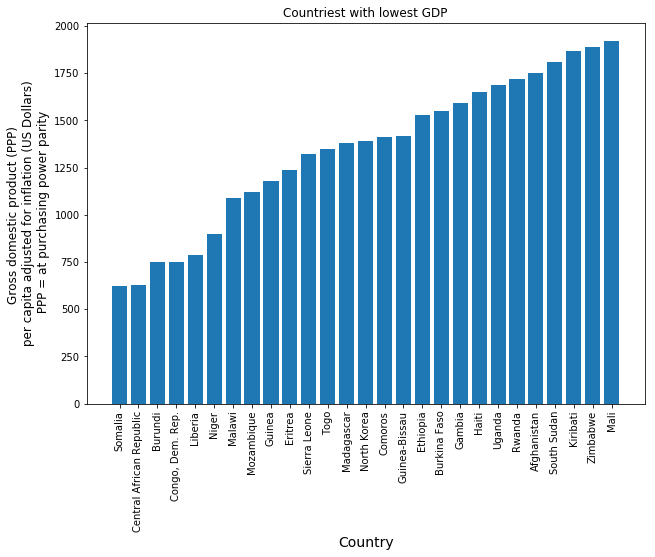

```python
#visualize the lowest countries
plt.figure(figsize=(10,7))
labels = inc[inc['levels2015'] == 'lowest'].sort_values(by='2015')['country']
labels
plt.bar(labels, inc[inc['levels2015'] == 'lowest'].sort_values(by='2015')['2015'])
plt.xticks(rotation=90);
plt.xlabel('Country', fontsize=14)
plt.ylabel('Gross domestic product (PPP) \n per capita adjusted for inflation (US Dollars) \n PPP = at purchasing power parity', fontsize=12);
plt.title('Countriest with lowest GDP');
```

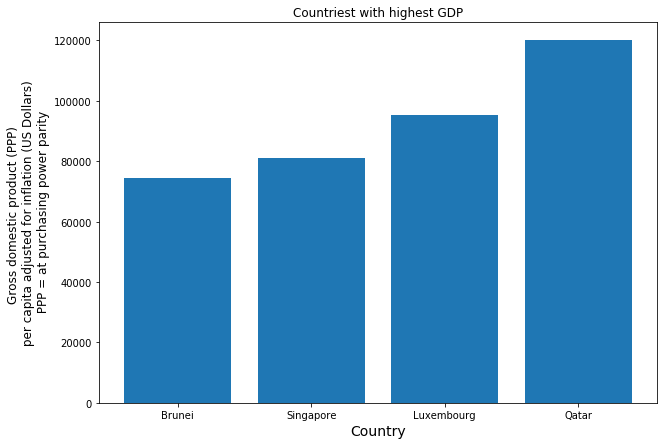

```python
#visualize the highest countries
plt.figure(figsize=(10,7))
labels = inc[inc['levels2015'] == 'highest'].sort_values(by='2015')['country']
labels
plt.bar(labels, inc[inc['levels2015'] == 'highest'].sort_values(by='2015')['2015'])
#plt.xticks(rotation=90);
plt.xlabel('Country', fontsize=14)
plt.ylabel('Gross domestic product (PPP) \n per capita adjusted for inflation (US Dollars) \n PPP = at purchasing power parity', fontsize=12);
plt.title('Countriest with highest GDP')
```

**B. Which countriest have highest and lowest child mortality rate?**

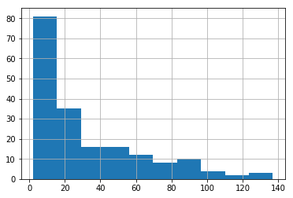

```python
#first visualize the overal GDP in PPP for 2015
M['2015'].hist();
#looks like it's a very right skewed distribution
```

```python
#Same procedure as above
#first figure out the 5 number summary for 2015 to make some bins
sum = M['2015'].describe()
sum
```

```
count    187.000000
mean     31.945989
std      31.618110
min      2.200000
25%      8.200000
50%      18.100000
75%      50.800000
max      137.000000
Name: 2015, dtype: float64
```

```python
#make bins
min1 = sum['min']
low = (min1 + sum['25%'])/2
low_med = sum['25%']
med = sum['50%']
med_high = sum['75%']
high = (med_high + sum['max'])/2
highest = sum['max']

bin_edges = [min1-0.001, low, low_med, med, med_high, high, highest]
bin_names = ['lowest', 'low', 'medium_low', 'medium', 'high', 'highest']
bin_edges
```

```
[2.1990000000000003, 5.199999999999999, 8.2, 18.1, 50.8, 93.9, 137.0]
```

```python
#add bins to the M df
M['levels2015'] = pd.cut(M['2015'], bin_edges, labels=bin_names)
```

```python
#check to make sure every entry got a level
M['levels2015'].isnull().any().sum()
```

```
0
```

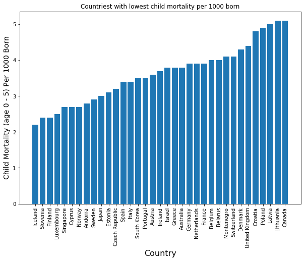

```python
#visualize the lowest
plt.figure(figsize=(10,7))
labels = M[M['levels2015'] == 'lowest'].sort_values(by='2015')['country']
labels
plt.bar(labels, M[M['levels2015'] == 'lowest'].sort_values(by='2015')['2015'])
plt.xticks(rotation=90);
plt.xlabel('Country', fontsize=16)
plt.ylabel('Child Mortality (age 0 - 5) Per 1000 Born', fontsize=14);
plt.title('Countriest with lowest child mortality per 1000 born');
```

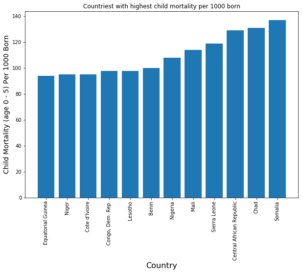

```python
#visualize the highest
plt.figure(figsize=(10,7))
labels = M[M['levels2015'] == 'highest'].sort_values(by='2015')['country']
labels
plt.bar(labels, M[M['levels2015'] == 'highest'].sort_values(by='2015')['2015'])
plt.xticks(rotation=90);
plt.xlabel('Country', fontsize=16)
plt.ylabel('Child Mortality (age 0 - 5) Per 1000 Born', fontsize=14);
plt.title('Countriest with highest child mortality per 1000 born');
```

**C. Which countriest have most and least educated?**

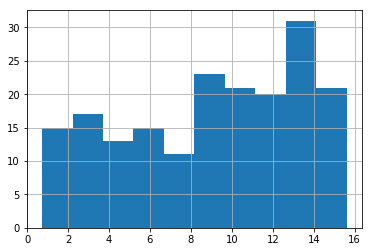

```python
#first visualize the overal GDP in PPP for 2015
school['2015'].hist();
#looks like it's a very right skewed distribution
```

```python
#first figure out the 5 number summary for 2015 to make some bins
sum = school['2015'].describe()
sum
```

```
count    187.000000
mean     9.006845
std      4.295344
min      0.740000
25%      5.565000
50%      9.620000
75%      12.900000
max      15.600000
Name: 2015, dtype: float64
```

```python
#make bins
min1 = sum['min']
low = (min1 + sum['25%'])/2
low_med = sum['25%']
med = sum['50%']
med_high = sum['75%']
high = (med_high + sum['max'])/2
highest = sum['max']

bin_edges = [min1-0.001, low, low_med, med, med_high, high, highest+0.001]
bin_names = ['lowest', 'low', 'medium_low', 'medium', 'high', 'highest']
bin_edges
```

```
[0.739, 3.1525, 5.5649999999999995, 9.62, 12.9, 14.25, 15.600999999999999]
```

```python
#add bins to the inc df
school['levels2015'] = pd.cut(school['2015'], bin_edges, labels=bin_names)

school['2015'].head(5)
```

```
0    0.74
1    12.00
2    4.33
3    13.90
4    4.49
Name: 2015, dtype: float64
```

```python
#check to make sure every entry got a level
school['levels2015'].isnull().any().sum()
```

```
0
```

```python
#select lowest countries and select highest countries
school[school['levels2015'] == 'lowest']
```

|  | country | 1970 | 1971 | 1972 | 1973 | 1974 | 1975 | 1976 | 1977 | 1978 | 1979 | 1980 | 1981 | 1982 | 1983 | 1984 | 1985 | 1986 | 1987 | 1988 | 1989 | 1990 | 1991 | 1992 | 1993 | 1994 | 1995 | 1996 | 1997 | … |
| --- | --- | --- | --- | --- | --- | --- | --- | --- | --- | --- | --- | --- | --- | --- | --- | --- | --- | --- | --- | --- | --- | --- | --- | --- | --- | --- | --- | --- | --- | --- |
| 0 | Afghanistan | 0.15 | 0.16 | 0.16 | 0.17 | 0.18 | 0.18 | 0.19 | 0.20 | 0.20 | 0.21 | 0.22 | 0.22 | 0.23 | 0.24 | 0.25 | 0.26 | 0.27 | 0.28 | 0.29 | 0.30 | 0.31 | 0.32 | 0.33 | 0.34 | 0.35 | 0.37 | 0.38 | 0.40 | … |
| 18 | Benin | 0.44 | 0.46 | 0.48 | 0.49 | 0.51 | 0.53 | 0.55 | 0.56 | 0.58 | 0.61 | 0.63 | 0.65 | 0.67 | 0.70 | 0.72 | 0.75 | 0.77 | 0.80 | 0.83 | 0.86 | 0.89 | 0.92 | 0.96 | 0.99 | 1.03 | 1.06 | 1.10 | 1.14 | … |
| 19 | Bhutan | 0.57 | 0.59 | 0.61 | 0.63 | 0.65 | 0.68 | 0.70 | 0.72 | 0.75 | 0.77 | 0.80 | 0.82 | 0.85 | 0.88 | 0.91 | 0.94 | 0.97 | 1.00 | 1.04 | 1.07 | 1.11 | 1.14 | 1.18 | 1.22 | 1.26 | 1.30 | 1.34 | 1.39 | … |
| 26 | Burkina Faso | 0.20 | 0.21 | 0.22 | 0.23 | 0.23 | 0.24 | 0.25 | 0.26 | 0.27 | 0.28 | 0.29 | 0.30 | 0.31 | 0.33 | 0.34 | 0.35 | 0.37 | 0.38 | 0.40 | 0.41 | 0.43 | 0.45 | 0.46 | 0.48 | 0.50 | 0.52 | 0.55 | 0.57 | … |
| 27 | Burundi | 0.65 | 0.67 | 0.70 | 0.72 | 0.75 | 0.77 | 0.80 | 0.83 | 0.85 | 0.88 | 0.91 | 0.95 | 0.98 | 1.01 | 1.05 | 1.08 | 1.12 | 1.16 | 1.20 | 1.24 | 1.28 | 1.33 | 1.37 | 1.42 | 1.47 | 1.52 | 1.58 | 1.63 | … |
| 32 | Central African Republic | 0.68 | 0.70 | 0.72 | 0.75 | 0.77 | 0.80 | 0.83 | 0.86 | 0.89 | 0.92 | 0.95 | 0.98 | 1.01 | 1.05 | 1.09 | 1.12 | 1.16 | 1.20 | 1.24 | 1.29 | 1.33 | 1.38 | 1.42 | 1.47 | 1.53 | 1.58 | 1.64 | 1.70 | … |
| 33 | Chad | 0.24 | 0.25 | 0.25 | 0.26 | 0.27 | 0.28 | 0.29 | 0.30 | 0.31 | 0.32 | 0.33 | 0.34 | 0.36 | 0.37 | 0.38 | 0.39 | 0.41 | 0.42 | 0.44 | 0.45 | 0.47 | 0.48 | 0.50 | 0.52 | 0.54 | 0.55 | 0.57 | 0.59 | … |
| 37 | Comoros | 0.63 | 0.65 | 0.67 | 0.69 | 0.72 | 0.75 | 0.77 | 0.80 | 0.83 | 0.86 | 0.89 | 0.92 | 0.95 | 0.99 | 1.03 | 1.06 | 1.10 | 1.14 | 1.18 | 1.23 | 1.27 | 1.32 | 1.37 | 1.42 | 1.48 | 1.53 | 1.59 | 1.66 | … |
| 41 | Cote d'Ivoire | 0.53 | 0.55 | 0.57 | 0.59 | 0.61 | 0.64 | 0.66 | 0.69 | 0.72 | 0.75 | 0.78 | 0.81 | 0.84 | 0.88 | 0.92 | 0.95 | 0.99 | 1.04 | 1.08 | 1.13 | 1.18 | 1.23 | 1.28 | 1.34 | 1.40 | 1.46 | 1.52 | 1.58 | … |
| 47 | Djibouti | 0.53 | 0.55 | 0.57 | 0.59 | 0.61 | 0.63 | 0.65 | 0.67 | 0.70 | 0.72 | 0.75 | 0.77 | 0.80 | 0.83 | 0.86 | 0.88 | 0.92 | 0.95 | 0.98 | 1.01 | 1.05 | 1.08 | 1.12 | 1.16 | 1.20 | 1.24 | 1.29 | 1.33 | … |
| 54 | Eritrea | 0.56 | 0.58 | 0.60 | 0.62 | 0.64 | 0.66 | 0.69 | 0.71 | 0.73 | 0.76 | 0.78 | 0.81 | 0.84 | 0.87 | 0.90 | 0.93 | 0.96 | 0.99 | 1.03 | 1.06 | 1.10 | 1.13 | 1.17 | 1.21 | 1.25 | 1.30 | 1.34 | 1.39 | … |
| 56 | Ethiopia | 0.44 | 0.46 | 0.47 | 0.49 | 0.51 | 0.52 | 0.54 | 0.56 | 0.58 | 0.60 | 0.62 | 0.65 | 0.67 | 0.69 | 0.72 | 0.74 | 0.77 | 0.79 | 0.82 | 0.85 | 0.88 | 0.91 | 0.94 | 0.97 | 1.01 | 1.04 | 1.08 | 1.11 | … |
| 61 | Gambia | 0.51 | 0.53 | 0.55 | 0.57 | 0.59 | 0.61 | 0.63 | 0.65 | 0.67 | 0.69 | 0.72 | 0.74 | 0.76 | 0.79 | 0.82 | 0.84 | 0.87 | 0.90 | 0.93 | 0.96 | 0.99 | 1.03 | 1.06 | 1.10 | 1.13 | 1.17 | 1.21 | 1.25 | … |
| 68 | Guinea | 0.26 | 0.27 | 0.28 | 0.29 | 0.30 | 0.31 | 0.32 | 0.33 | 0.34 | 0.36 | 0.37 | 0.39 | 0.40 | 0.42 | 0.43 | 0.45 | 0.47 | 0.49 | 0.51 | 0.53 | 0.55 | 0.58 | 0.60 | 0.63 | 0.65 | 0.68 | 0.71 | 0.74 | … |
| 69 | Guinea-Bissau | 0.29 | 0.30 | 0.31 | 0.33 | 0.34 | 0.35 | 0.36 | 0.37 | 0.39 | 0.40 | 0.42 | 0.43 | 0.45 | 0.46 | 0.48 | 0.50 | 0.51 | 0.53 | 0.55 | 0.57 | 0.59 | 0.62 | 0.64 | 0.66 | 0.69 | 0.71 | 0.74 | 0.77 | … |
| 103 | Mali | 0.22 | 0.23 | 0.24 | 0.25 | 0.25 | 0.26 | 0.28 | 0.29 | 0.30 | 0.31 | 0.32 | 0.33 | 0.35 | 0.36 | 0.38 | 0.39 | 0.41 | 0.43 | 0.44 | 0.46 | 0.48 | 0.50 | 0.53 | 0.55 | 0.57 | 0.60 | 0.62 | 0.65 | … |
| 106 | Mauritania | 0.74 | 0.76 | 0.79 | 0.81 | 0.84 | 0.86 | 0.89 | 0.92 | 0.95 | 0.98 | 1.00 | 1.03 | 1.07 | 1.10 | 1.13 | 1.16 | 1.19 | 1.22 | 1.26 | 1.29 | 1.33 | 1.36 | 1.40 | 1.43 | 1.47 | 1.50 | 1.54 | 1.58 | … |
| 113 | Morocco | 0.61 | 0.63 | 0.66 | 0.68 | 0.71 | 0.73 | 0.76 | 0.79 | 0.82 | 0.85 | 0.88 | 0.92 | 0.95 | 0.99 | 1.03 | 1.07 | 1.11 | 1.15 | 1.20 | 1.25 | 1.30 | 1.35 | 1.40 | 1.46 | 1.52 | 1.59 | 1.65 | 1.71 | … |
| 114 | Mozambique | 0.73 | 0.75 | 0.78 | 0.80 | 0.83 | 0.86 | 0.89 | 0.92 | 0.95 | 0.98 | 1.01 | 1.05 | 1.08 | 1.12 | 1.15 | 1.19 | 1.23 | 1.27 | 1.32 | 1.36 | 1.40 | 1.45 | 1.50 | 1.55 | 1.60 | 1.65 | 1.70 | 1.76 | … |
| 117 | Nepal | 0.27 | 0.28 | 0.29 | 0.30 | 0.32 | 0.33 | 0.34 | 0.36 | 0.37 | 0.39 | 0.41 | 0.42 | 0.44 | 0.46 | 0.48 | 0.51 | 0.53 | 0.55 | 0.58 | 0.60 | 0.63 | 0.66 | 0.69 | 0.73 | 0.76 | 0.80 | 0.84 | 0.87 | … |
| 121 | Niger | 0.17 | 0.18 | 0.18 | 0.19 | 0.20 | 0.20 | 0.21 | 0.22 | 0.23 | 0.23 | 0.24 | 0.25 | 0.26 | 0.27 | 0.28 | 0.29 | 0.30 | 0.31 | 0.32 | 0.33 | 0.35 | 0.36 | 0.37 | 0.39 | 0.40 | 0.42 | 0.43 | 0.45 | … |
| 126 | Pakistan | 0.51 | 0.53 | 0.55 | 0.57 | 0.60 | 0.62 | 0.64 | 0.67 | 0.70 | 0.72 | 0.75 | 0.78 | 0.82 | 0.85 | 0.89 | 0.92 | 0.96 | 1.00 | 1.05 | 1.09 | 1.14 | 1.19 | 1.24 | 1.30 | 1.36 | 1.42 | 1.48 | 1.54 | … |
| 142 | Senegal | 0.44 | 0.46 | 0.48 | 0.50 | 0.52 | 0.53 | 0.56 | 0.58 | 0.60 | 0.62 | 0.65 | 0.67 | 0.70 | 0.72 | 0.75 | 0.78 | 0.81 | 0.85 | 0.88 | 0.91 | 0.95 | 0.99 | 1.03 | 1.07 | 1.12 | 1.16 | 1.21 | 1.25 | … |
| 145 | Sierra Leone | 0.43 | 0.44 | 0.46 | 0.48 | 0.50 | 0.52 | 0.53 | 0.55 | 0.58 | 0.60 | 0.62 | 0.64 | 0.67 | 0.69 | 0.72 | 0.75 | 0.78 | 0.81 | 0.84 | 0.87 | 0.90 | 0.94 | 0.97 | 1.01 | 1.05 | 1.09 | 1.12 | 1.16 | … |
| 150 | Somalia | 0.43 | 0.44 | 0.46 | 0.47 | 0.49 | 0.51 | 0.52 | 0.54 | 0.56 | 0.58 | 0.60 | 0.62 | 0.64 | 0.66 | 0.68 | 0.71 | 0.73 | 0.75 | 0.78 | 0.80 | 0.83 | 0.86 | 0.89 | 0.92 | 0.95 | 0.98 | 1.01 | 1.04 | … |
| 153 | South Sudan | 0.20 | 0.20 | 0.21 | 0.22 | 0.23 | 0.23 | 0.24 | 0.25 | 0.26 | 0.27 | 0.28 | 0.29 | 0.29 | 0.30 | 0.32 | 0.33 | 0.34 | 0.35 | 0.36 | 0.37 | 0.39 | 0.40 | 0.41 | 0.43 | 0.44 | 0.45 | 0.47 | 0.49 | … |
| 184 | Yemen | 0.11 | 0.11 | 0.12 | 0.12 | 0.13 | 0.13 | 0.14 | 0.15 | 0.15 | 0.16 | 0.17 | 0.18 | 0.19 | 0.20 | 0.21 | 0.22 | 0.23 | 0.24 | 0.25 | 0.27 | 0.28 | 0.30 | 0.32 | 0.34 | 0.36 | 0.39 | 0.41 | 0.44 | … |

```python
school[school['levels2015'] == 'highest']
```

|  | country | 1970 | 1971 | 1972 | 1973 | 1974 | 1975 | 1976 | 1977 | 1978 | 1979 | 1980 | 1981 | 1982 | 1983 | 1984 | 1985 | 1986 | 1987 | 1988 | 1989 | 1990 | 1991 | 1992 | 1993 | 1994 | 1995 | 1996 | 1997 | … |
| --- | --- | --- | --- | --- | --- | --- | --- | --- | --- | --- | --- | --- | --- | --- | --- | --- | --- | --- | --- | --- | --- | --- | --- | --- | --- | --- | --- | --- | --- | --- |
| 15 | Belarus | 7.25 | 7.40 | 7.56 | 7.72 | 7.88 | 8.04 | 8.21 | 8.37 | 8.53 | 8.70 | 8.86 | 9.03 | 9.20 | 9.37 | 9.54 | 9.70 | 9.87 | 10.00 | 10.2 | 10.4 | 10.6 | 10.7 | 10.9 | 11.1 | 11.2 | 11.4 | 11.6 | 11.8 | … |
| 30 | Canada | 9.39 | 9.58 | 9.77 | 9.96 | 10.20 | 10.30 | 10.50 | 10.70 | 10.90 | 11.10 | 11.30 | 11.40 | 11.60 | 11.80 | 11.90 | 12.10 | 12.20 | 12.40 | 12.5 | 12.7 | 12.8 | 12.9 | 13.1 | 13.2 | 13.3 | 13.4 | 13.5 | 13.6 | … |
| 45 | Czech Republic | 7.49 | 7.65 | 7.81 | 7.98 | 8.14 | 8.31 | 8.48 | 8.64 | 8.81 | 8.98 | 9.15 | 9.32 | 9.49 | 9.65 | 9.82 | 9.99 | 10.20 | 10.30 | 10.5 | 10.7 | 10.8 | 11.0 | 11.1 | 11.3 | 11.4 | 11.6 | 11.7 | 11.9 | … |
| 46 | Denmark | 8.22 | 8.38 | 8.54 | 8.71 | 8.87 | 9.04 | 9.21 | 9.37 | 9.54 | 9.70 | 9.87 | 10.00 | 10.20 | 10.40 | 10.50 | 10.70 | 10.90 | 11.00 | 11.2 | 11.3 | 11.5 | 11.7 | 11.8 | 12.0 | 12.1 | 12.3 | 12.4 | 12.6 | … |
| 55 | Estonia | 7.27 | 7.43 | 7.59 | 7.75 | 7.92 | 8.08 | 8.25 | 8.41 | 8.58 | 8.75 | 8.92 | 9.10 | 9.27 | 9.44 | 9.62 | 9.79 | 9.97 | 10.20 | 10.3 | 10.5 | 10.7 | 10.8 | 11.0 | 11.2 | 11.4 | 11.6 | 11.7 | 11.9 | … |
| 58 | Finland | 7.61 | 7.77 | 7.94 | 8.10 | 8.27 | 8.43 | 8.60 | 8.77 | 8.94 | 9.11 | 9.28 | 9.45 | 9.62 | 9.80 | 9.97 | 10.10 | 10.30 | 10.50 | 10.7 | 10.8 | 11.0 | 11.2 | 11.3 | 11.5 | 11.7 | 11.8 | 12.0 | 12.2 | … |
| 62 | Georgia | 7.23 | 7.39 | 7.55 | 7.72 | 7.88 | 8.05 | 8.21 | 8.38 | 8.55 | 8.72 | 8.88 | 9.05 | 9.22 | 9.39 | 9.56 | 9.73 | 9.90 | 10.10 | 10.2 | 10.4 | 10.6 | 10.7 | 10.9 | 11.1 | 11.2 | 11.4 | 11.5 | 11.7 | … |
| 74 | Iceland | 7.72 | 7.88 | 8.05 | 8.21 | 8.38 | 8.55 | 8.71 | 8.88 | 9.05 | 9.22 | 9.39 | 9.56 | 9.74 | 9.91 | 10.10 | 10.30 | 10.40 | 10.60 | 10.8 | 10.9 | 11.1 | 11.3 | 11.4 | 11.6 | 11.8 | 11.9 | 12.1 | 12.3 | … |
| 80 | Israel | 8.31 | 8.48 | 8.65 | 8.82 | 8.99 | 9.16 | 9.34 | 9.51 | 9.68 | 9.85 | 10.00 | 10.20 | 10.40 | 10.50 | 10.70 | 10.90 | 11.00 | 11.20 | 11.4 | 11.5 | 11.7 | 11.9 | 12.0 | 12.2 | 12.3 | 12.5 | 12.6 | 12.8 | … |
| 83 | Japan | 8.21 | 8.37 | 8.53 | 8.69 | 8.84 | 9.00 | 9.16 | 9.32 | 9.47 | 9.63 | 9.79 | 9.94 | 10.10 | 10.30 | 10.40 | 10.60 | 10.70 | 10.90 | 11.0 | 11.2 | 11.3 | 11.5 | 11.6 | 11.8 | 11.9 | 12.1 | 12.2 | 12.4 | … |
| 91 | Latvia | 7.75 | 7.91 | 8.08 | 8.24 | 8.41 | 8.57 | 8.74 | 8.91 | 9.07 | 9.24 | 9.41 | 9.57 | 9.74 | 9.90 | 10.10 | 10.20 | 10.40 | 10.60 | 10.7 | 10.9 | 11.0 | 11.2 | 11.3 | 11.5 | 11.6 | 11.8 | 11.9 | 12.0 | … |
| 119 | New Zealand | 7.32 | 7.48 | 7.64 | 7.81 | 7.97 | 8.14 | 8.31 | 8.48 | 8.65 | 8.82 | 9.00 | 9.18 | 9.36 | 9.54 | 9.72 | 9.90 | 10.10 | 10.30 | 10.4 | 10.6 | 10.8 | 11.0 | 11.2 | 11.3 | 11.5 | 11.7 | 11.9 | 12.0 | … |
| 124 | Norway | 7.71 | 7.87 | 8.03 | 8.20 | 8.36 | 8.53 | 8.70 | 8.87 | 9.04 | 9.21 | 9.38 | 9.55 | 9.73 | 9.90 | 10.10 | 10.30 | 10.40 | 10.60 | 10.8 | 10.9 | 11.1 | 11.3 | 11.5 | 11.6 | 11.8 | 12.0 | 12.2 | 12.3 | … |
| 133 | Poland | 7.65 | 7.81 | 7.97 | 8.14 | 8.30 | 8.46 | 8.62 | 8.78 | 8.94 | 9.10 | 9.26 | 9.42 | 9.58 | 9.74 | 9.89 | 10.10 | 10.20 | 10.40 | 10.5 | 10.7 | 10.8 | 11.0 | 11.1 | 11.3 | 11.4 | 11.5 | 11.7 | 11.8 | … |
| 137 | Russia | 7.76 | 7.93 | 8.09 | 8.26 | 8.43 | 8.59 | 8.76 | 8.93 | 9.10 | 9.26 | 9.43 | 9.60 | 9.76 | 9.93 | 10.10 | 10.30 | 10.40 | 10.60 | 10.7 | 10.9 | 11.0 | 11.2 | 11.3 | 11.5 | 11.6 | 11.8 | 11.9 | 12.1 | … |
| 161 | Sweden | 7.88 | 8.05 | 8.21 | 8.38 | 8.55 | 8.71 | 8.88 | 9.05 | 9.22 | 9.39 | 9.56 | 9.72 | 9.89 | 10.10 | 10.20 | 10.40 | 10.60 | 10.70 | 10.9 | 11.0 | 11.2 | 11.3 | 11.5 | 11.7 | 11.8 | 11.9 | 12.1 | 12.3 | … |
| 175 | Ukraine | 6.77 | 6.94 | 7.11 | 7.29 | 7.46 | 7.64 | 7.82 | 8.00 | 8.18 | 8.36 | 8.55 | 8.74 | 8.93 | 9.12 | 9.31 | 9.50 | 9.69 | 9.88 | 10.1 | 10.3 | 10.5 | 10.7 | 10.8 | 11.0 | 11.2 | 11.4 | 11.6 | 11.8 | … |
| 177 | United Kingdom | 7.28 | 7.44 | 7.60 | 7.76 | 7.92 | 8.08 | 8.24 | 8.41 | 8.57 | 8.74 | 8.90 | 9.07 | 9.24 | 9.40 | 9.57 | 9.74 | 9.91 | 10.10 | 10.2 | 10.4 | 10.6 | 10.7 | 10.9 | 11.1 | 11.2 | 11.4 | 11.6 | 11.7 | … |
| 178 | United States | 11.20 | 11.40 | 11.50 | 11.60 | 11.80 | 11.90 | 12.00 | 12.10 | 12.20 | 12.30 | 12.40 | 12.50 | 12.60 | 12.70 | 12.80 | 12.90 | 13.00 | 13.00 | 13.1 | 13.2 | 13.2 | 13.3 | 13.3 | 13.3 | 13.4 | 13.4 | 13.4 | 13.5 | … |

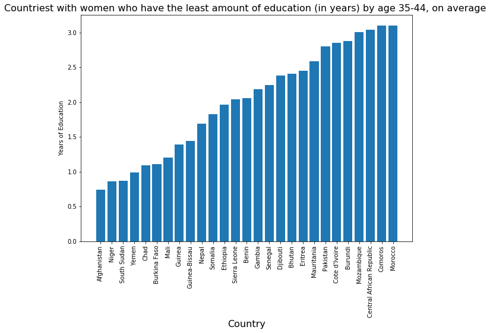

```python
#visualize the lowest countries
plt.figure(figsize=(10,7))
labels = school[school['levels2015'] == 'lowest'].sort_values(by='2015')['country']
labels
plt.bar(labels, school[school['levels2015'] == 'lowest'].sort_values(by='2015')['2015'])
plt.xticks(rotation=90);
plt.xlabel('Country', fontsize=16)
plt.ylabel('Years of Education')
plt.title("Countriest with women who have the least amount of education (in years) by age 35-44, on average ", fontsize=16);
```

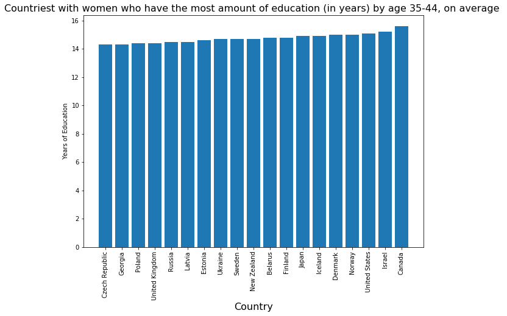

```python
#visualize the highest countries
plt.figure(figsize=(10,7))
labels = school[school['levels2015'] == 'highest'].sort_values(by='2015')['country']
labels
plt.bar(labels, school[school['levels2015'] == 'highest'].sort_values(by='2015')['2015'])
plt.xticks(rotation=90);
plt.xlabel('Country', fontsize=16)
plt.ylabel('Years of Education')
plt.title("Countriest with women who have the most amount of education (in years) by age 35-44, on average ", fontsize=16);
```

### Research Question 2: Where have there been increases, where have these indicators been stagnant?

> A. Where has GDP increased the most since 1970? Where has GDP growth been stagnant?  
> B. Where has mortality rate decreased the most since 1970? Where has mortality rate been stagnant? Has there been an increase in mortality rate anywhere?  
> C. Where has education rate of women increased the most since 1970? Where has it been stagnant?

**A. Where has GDP increased the most since 1970? Where has GDP growth been stagnant? Where has there been a decline?**

```python
#make rate of increase column`
inc['rate'] = ((inc['2015']-inc['1970'])/inc['1970']) *100
M['rate'] = ((M['2015']-M['1970'])/M['1970']) *100
school['rate'] = ((school['2015']-school['1970'])/school['1970']) *100
```

```python
sum = inc['rate'].describe()
sum
```

```
count    187.000000
mean     160.196880
std      264.111496
min     -79.483283
25%      45.547786
50%      97.540984
75%      187.027169
max      2265.217391
Name: rate, dtype: float64
```

```python
#make bins

dec = sum['min']
min1 = 0
low = (min1 + sum['25%'])/2
low_med = sum['25%']
med = sum['50%']
med_high = sum['75%']
high = (med_high + sum['max'])/2
highest = sum['max']



bin_edges = [dec-0.001, min1, low, low_med, med, med_high, high, highest+0.001]
bin_names = ['decreasing', 'lowest', 'low', 'medium_low', 'medium', 'high', 'highest']
bin_edges
```

```
[-79.48428267477205,
 0,
 22.773892773892776,
 45.54778554778555,
 97.54098360655738,
 187.02716944044806,
 1226.1222803723979,
 2265.2183913043477]
```

```python
inc[inc['rate'] == dec]
```

|  | country | 1970 | 1971 | 1972 | 1973 | 1974 | 1975 | 1976 | 1977 | 1978 | 1979 | 1980 | 1981 | 1982 | 1983 | 1984 | 1985 | 1986 | 1987 | 1988 | 1989 | 1990 | 1991 | 1992 | 1993 | 1994 | 1995 | 1996 | 1997 | … |
| --- | --- | --- | --- | --- | --- | --- | --- | --- | --- | --- | --- | --- | --- | --- | --- | --- | --- | --- | --- | --- | --- | --- | --- | --- | --- | --- | --- | --- | --- | --- |
| 95 | Libya | 65800 | 60200 | 51400 | 49500 | 40300 | 41700 | 50000 | 53600 | 54400 | 59400 | 57700 | 44100 | 42700 | 39000 | 34300 | 34700 | 29600 | 24200 | 23100 | 23600 | 26000 | 29400 | 27900 | 26300 | 26300 | 22600 | 22700 | 22200 | … |

```python
#add bins to the inc df
inc['level_rate'] = pd.cut(inc['rate'], bin_edges, labels=bin_names)

inc['level_rate'].head(5)
```

```
0    medium_low
1    high
2    medium_low
3    low
4    lowest
Name: level_rate, dtype: category
Categories (7, object): [decreasing < lowest < low < medium_low < medium < high < highest]
```

```python
#check to make sure every entry got a level
inc['level_rate'].isnull().any().sum()
```

```
0
```

```python
inc[inc['level_rate'].isnull()]
```

|  | country | 1970 | 1971 | 1972 | 1973 | 1974 | 1975 | 1976 | 1977 | 1978 | 1979 | 1980 | 1981 | 1982 | 1983 | 1984 | 1985 | 1986 | 1987 | 1988 | 1989 | 1990 | 1991 | 1992 | 1993 | 1994 | 1995 | 1996 | 1997 | … |
| --- | --- | --- | --- | --- | --- | --- | --- | --- | --- | --- | --- | --- | --- | --- | --- | --- | --- | --- | --- | --- | --- | --- | --- | --- | --- | --- | --- | --- | --- | --- |

```python
#select lowest countries and select highest countries
inc[inc['level_rate'] == 'lowest']
```

|  | country | 1970 | 1971 | 1972 | 1973 | 1974 | 1975 | 1976 | 1977 | 1978 | 1979 | 1980 | 1981 | 1982 | 1983 | 1984 | 1985 | 1986 | 1987 | 1988 | 1989 | 1990 | 1991 | 1992 | 1993 | 1994 | 1995 | 1996 | 1997 | … |
| --- | --- | --- | --- | --- | --- | --- | --- | --- | --- | --- | --- | --- | --- | --- | --- | --- | --- | --- | --- | --- | --- | --- | --- | --- | --- | --- | --- | --- | --- | --- |
| 4 | Angola | 5550 | 5780 | 5670 | 6000 | 6060 | 5620 | 5200 | 5110 | 4720 | 4610 | 4590 | 4250 | 4110 | 4140 | 4240 | 4260 | 4290 | 4480 | 4620 | 4530 | 4390 | 4210 | 3790 | 2760 | 2770 | 2970 | 3210 | 3370 | … |
| 11 | Bahamas | 21200 | 21000 | 19900 | 21000 | 17100 | 14300 | 14800 | 15800 | 17700 | 21800 | 22700 | 21600 | 22500 | 23600 | 23600 | 24200 | 24300 | 24800 | 25000 | 25100 | 24300 | 22800 | 21600 | 21200 | 21500 | 22100 | 22700 | 23000 | … |
| 54 | Eritrea | 1090 | 1110 | 1120 | 1120 | 1090 | 1020 | 999 | 983 | 913 | 994 | 997 | 999 | 981 | 1030 | 970 | 832 | 884 | 975 | 950 | 915 | 908 | 1000 | 1110 | 1270 | 1540 | 1590 | 1720 | 1830 | … |
| 61 | Gambia | 1480 | 1600 | 1660 | 1680 | 1960 | 1780 | 1920 | 1960 | 1800 | 2030 | 1770 | 1700 | 1860 | 1590 | 1490 | 1320 | 1350 | 1370 | 1460 | 1510 | 1520 | 1510 | 1510 | 1510 | 1480 | 1450 | 1440 | 1470 | … |
| 68 | Guinea | 963 | 975 | 976 | 1000 | 1050 | 1070 | 1160 | 1160 | 1170 | 1150 | 1160 | 1150 | 1140 | 1130 | 1110 | 1080 | 1070 | 1080 | 1120 | 1140 | 1120 | 1090 | 1070 | 1060 | 1040 | 1040 | 1060 | 1080 | … |
| 82 | Jamaica | 7800 | 7690 | 7780 | 8310 | 7850 | 7700 | 7120 | 6870 | 6830 | 6610 | 6170 | 6230 | 6190 | 6300 | 6210 | 5890 | 5960 | 6390 | 6550 | 6960 | 7290 | 7580 | 7660 | 8300 | 8330 | 8450 | 8360 | 8180 | … |
| 92 | Lebanon | 12100 | 13100 | 14400 | 14800 | 15000 | 10400 | 4370 | 7510 | 7700 | 8710 | 9240 | 9310 | 5900 | 7140 | 10300 | 12900 | 12200 | 14300 | 10300 | 5990 | 7860 | 10700 | 10900 | 11300 | 11900 | 12500 | 12900 | 12500 | … |
| 106 | Mauritania | 2970 | 2960 | 2960 | 2750 | 2990 | 2760 | 2940 | 2860 | 2800 | 2890 | 2950 | 3010 | 2890 | 2970 | 2700 | 2720 | 2810 | 2830 | 2870 | 2910 | 2810 | 2780 | 2760 | 2840 | 2680 | 2860 | 2940 | 2740 | … |
| 145 | Saudi Arabia | 45500 | 53600 | 60500 | 65100 | 103000 | 78400 | 92600 | 89600 | 82400 | 80900 | 84300 | 78700 | 65000 | 58100 | 52500 | 42800 | 41600 | 38000 | 38000 | 38300 | 42500 | 47300 | 47700 | 45800 | 44900 | 44000 | 44200 | 43800 | … |
| 146 | Senegal | 2030 | 1970 | 2030 | 1870 | 1890 | 1980 | 2120 | 2000 | 1860 | 1930 | 1810 | 1750 | 1950 | 1940 | 1800 | 1810 | 1840 | 1860 | 1900 | 1810 | 1840 | 1830 | 1800 | 1770 | 1720 | 1760 | 1750 | 1760 | … |
| 188 | Venezuela | 15300 | 15500 | 15600 | 16300 | 17000 | 17600 | 18900 | 19500 | 19400 | 19000 | 18000 | 17400 | 16600 | 14900 | 14100 | 13800 | 14000 | 14700 | 15400 | 14000 | 14500 | 15500 | 16100 | 15800 | 15100 | 15300 | 15000 | 15600 | … |

```python
inc[inc['level_rate'] == 'highest']
```

|  | country | 1970 | 1971 | 1972 | 1973 | 1974 | 1975 | 1976 | 1977 | 1978 | 1979 | 1980 | 1981 | 1982 | 1983 | 1984 | 1985 | 1986 | 1987 | 1988 | 1989 | 1990 | 1991 | 1992 | 1993 | 1994 | 1995 | 1996 | 1997 | … |
| --- | --- | --- | --- | --- | --- | --- | --- | --- | --- | --- | --- | --- | --- | --- | --- | --- | --- | --- | --- | --- | --- | --- | --- | --- | --- | --- | --- | --- | --- | --- |
| 35 | China | 851 | 879 | 846 | 898 | 892 | 924 | 896 | 909 | 1020 | 1060 | 1080 | 1110 | 1180 | 1240 | 1460 | 1570 | 1610 | 1660 | 1610 | 1480 | 1530 | 1650 | 1860 | 2090 | 2340 | 2560 | 2790 | 3020 | … |
| 53 | Equatorial Guinea | 1150 | 1040 | 899 | 936 | 991 | 1140 | 1270 | 1280 | 1380 | 1350 | 1290 | 1250 | 1240 | 1200 | 1120 | 1190 | 1100 | 1110 | 1100 | 1060 | 1000 | 958 | 1250 | 1340 | 1510 | 1720 | 2750 | 6620 | … |
| 156 | South Korea | 2080 | 2360 | 2680 | 3230 | 3570 | 3990 | 4470 | 4810 | 5210 | 5330 | 4740 | 4990 | 5300 | 5870 | 6380 | 6730 | 7710 | 8770 | 9860 | 10600 | 11600 | 12700 | 13400 | 14100 | 15300 | 16600 | 17700 | 18500 | … |

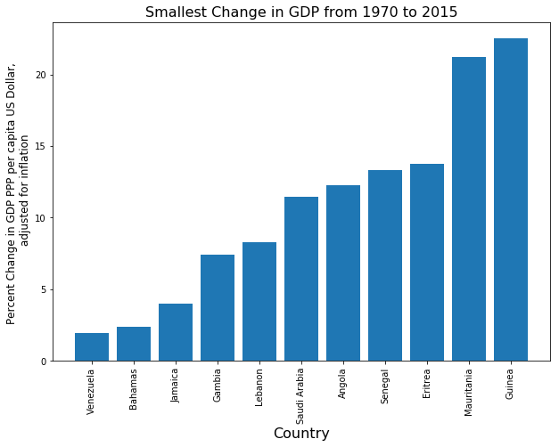

```python
#visualize the slowest growing
plt.figure(figsize=(10,7))
labels = inc[inc['level_rate'] == 'lowest'].sort_values(by='rate')['country']
labels
plt.bar(labels, inc[inc['level_rate'] == 'lowest'].sort_values(by='rate')['rate'])
plt.xticks(rotation=90);
plt.xlabel('Country', fontsize=16)
plt.ylabel("Percent Change in GDP PPP per capita US Dollar, \n adjusted for inflation", fontsize=12);
plt.title('Smallest Change in GDP from 1970 to 2015', fontsize=16);
```

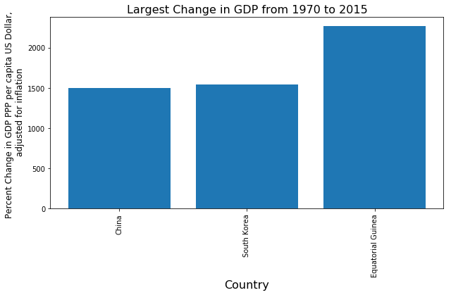

```python
#visualize the fastest growing
plt.figure(figsize=(10,5))
labels = inc[inc['level_rate'] == 'highest'].sort_values(by='rate')['country']
labels
plt.bar(labels, inc[inc['level_rate'] == 'highest'].sort_values(by='rate')['rate'])
plt.xticks(rotation=90);
plt.xlabel('Country', fontsize=16)
plt.ylabel("Percent Change in GDP PPP per capita US Dollar, \n adjusted for inflation", fontsize=12);
plt.title('Largest Change in GDP from 1970 to 2015', fontsize=16);
```

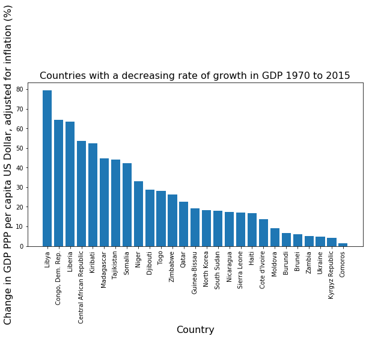

```python
#visualize the countries decreasing
plt.figure(figsize=(10,5))
labels = inc[inc['level_rate'] == 'decreasing'].sort_values(by='rate')['country']
labels
plt.bar(labels, inc[inc['level_rate'] == 'decreasing'].sort_values(by='rate')['rate']*-1)
plt.xticks(rotation=90);
plt.xlabel('Country', fontsize=16)
plt.ylabel("Change in GDP PPP per capita US Dollar, adjusted for inflation (%)", fontsize=16);
plt.title('Countries with a decreasing rate of growth in GDP 1970 to 2015', fontsize=16);
```

**B. Where has mortality rate decreased the most since 1970? Where has mortality rate been stagnant? Has there been an increase in mortality rate anywhere?**

```python
#make rate of increase column`
M['rate'] = ((M['2015']-M['1970'])/M['1970']) *100
```

```python
sum = M['rate'].describe()
sum
```

```
count    187.000000
mean    -77.129728
std      11.631910
min     -96.551724
25%     -86.339623
50%     -79.047619
75%     -70.404132
max     -41.363636
Name: rate, dtype: float64
```

```python
#make bins


min1 = sum['min']
low = (min1 + sum['25%'])/2
low_med = sum['25%']
med = sum['50%']
med_high = sum['75%']
high = (med_high + sum['max'])/2
highest = sum['max']



bin_edges = [ min1-0.001, low, low_med, med, med_high, high, highest]
bin_names = ['highest', 'high', 'medium high', 'medium', 'medium_low', 'low']
bin_edges
```

```
[-96.55272413793104,
 -91.44567338972024,
 -86.33962264150944,
 -79.04761904761905,
 -70.40413163426169,
 -55.88388399894903,
 -41.36363636363637]
```

```python
#add bins to the inc df
M['level_rate'] = pd.cut(M['rate'], bin_edges, labels=bin_names)

M['level_rate'].head(5)
```

```
0    medium
1    high
2    high
3    medium
4    medium_low
Name: level_rate, dtype: category
Categories (6, object): [highest < high < medium high < medium < medium_low < low]
```

```python
#check to make sure every entry got a level
M['level_rate'].isnull().any().sum()
```

```
0
```

```python
#select countries with smallest decrease in mortality rate
M[M['level_rate'] == 'low']
```

|  | country | 1970 | 1971 | 1972 | 1973 | 1974 | 1975 | 1976 | 1977 | 1978 | 1979 | 1980 | 1981 | 1982 | 1983 | 1984 | 1985 | 1986 | 1987 | 1988 | 1989 | 1990 | 1991 | 1992 | 1993 | 1994 | 1995 | 1996 | 1997 | … |
| --- | --- | --- | --- | --- | --- | --- | --- | --- | --- | --- | --- | --- | --- | --- | --- | --- | --- | --- | --- | --- | --- | --- | --- | --- | --- | --- | --- | --- | --- | --- |
| 32 | Central African Republic | 220.0 | 215.0 | 210.0 | 205.0 | 201.0 | 197.0 | 194.0 | 191.0 | 187.0 | 185.0 | 182.0 | 180.0 | 179.0 | 178.0 | 177.0 | 176.0 | 176.0 | 175.0 | 174.0 | 174.0 | 174.0 | 174.0 | 174.0 | 174.0 | 175.0 | 175.0 | 175.0 | 175.0 | … |
| 33 | Chad | 256.0 | 252.0 | 248.0 | 247.0 | 245.0 | 244.0 | 243.0 | 242.0 | 240.0 | 239.0 | 237.0 | 235.0 | 232.0 | 230.0 | 227.0 | 225.0 | 222.0 | 219.0 | 216.0 | 214.0 | 211.0 | 208.0 | 206.0 | 203.0 | 201.0 | 199.0 | 196.0 | 194.0 | … |
| 48 | Dominica | 64.4 | 58.2 | 51.7 | 45.2 | 39.3 | 34.1 | 29.7 | 26.1 | 23.3 | 21.1 | 19.5 | 18.3 | 17.5 | 17.0 | 16.8 | 16.7 | 16.7 | 16.8 | 16.9 | 17.0 | 17.1 | 17.1 | 17.1 | 17.0 | 16.8 | 16.6 | 16.3 | 16.0 | … |
| 70 | Guyana | 73.6 | 73.3 | 73.1 | 72.9 | 72.7 | 72.5 | 72.1 | 71.7 | 71.2 | 70.6 | 70.0 | 69.4 | 68.7 | 67.9 | 67.2 | 66.3 | 65.3 | 64.3 | 63.0 | 61.6 | 60.1 | 58.5 | 56.9 | 55.4 | 53.9 | 52.5 | 51.2 | 49.9 | … |
| 93 | Lesotho | 178.0 | 174.0 | 169.0 | 165.0 | 160.0 | 155.0 | 149.0 | 143.0 | 137.0 | 131.0 | 125.0 | 119.0 | 114.0 | 109.0 | 105.0 | 102.0 | 98.7 | 96.1 | 94.0 | 92.4 | 91.3 | 90.7 | 90.8 | 91.9 | 93.8 | 96.5 | 99.6 | 103.0 | … |
| 117 | Namibia | 96.8 | 97.4 | 98.0 | 98.5 | 99.2 | 99.8 | 100.0 | 101.0 | 101.0 | 100.0 | 99.4 | 97.9 | 95.8 | 93.1 | 90.0 | 86.7 | 83.2 | 79.9 | 76.7 | 73.8 | 71.3 | 69.2 | 67.7 | 67.0 | 67.0 | 67.7 | 68.9 | 70.4 | … |
| 154 | Somalia | 235.0 | 232.0 | 229.0 | 226.0 | 223.0 | 219.0 | 216.0 | 213.0 | 210.0 | 206.0 | 203.0 | 201.0 | 198.0 | 195.0 | 193.0 | 191.0 | 190.0 | 188.0 | 186.0 | 184.0 | 181.0 | 178.0 | 176.0 | 175.0 | 174.0 | 174.0 | 174.0 | 174.0 | … |
| 192 | Zimbabwe | 113.0 | 112.0 | 111.0 | 110.0 | 110.0 | 110.0 | 109.0 | 109.0 | 108.0 | 106.0 | 103.0 | 99.2 | 94.4 | 89.0 | 84.1 | 79.9 | 76.7 | 74.6 | 73.7 | 73.9 | 75.2 | 77.4 | 80.2 | 83.4 | 86.8 | 90.1 | 92.8 | 94.7 | … |

```python
#select countries with largest decrease in mortality rate
M[M['level_rate'] == 'highest']
```

|  | country | 1970 | 1971 | 1972 | 1973 | 1974 | 1975 | 1976 | 1977 | 1978 | 1979 | 1980 | 1981 | 1982 | 1983 | 1984 | 1985 | 1986 | 1987 | 1988 | 1989 | 1990 | 1991 | 1992 | 1993 | 1994 | 1995 | 1996 | 1997 | … |
| --- | --- | --- | --- | --- | --- | --- | --- | --- | --- | --- | --- | --- | --- | --- | --- | --- | --- | --- | --- | --- | --- | --- | --- | --- | --- | --- | --- | --- | --- | --- |
| 44 | Cyprus | 35.1 | 33.4 | 31.8 | 30.3 | 28.8 | 27.4 | 26.1 | 24.8 | 23.6 | 22.5 | 20.8 | 19.2 | 17.6 | 16.1 | 14.7 | 13.5 | 12.5 | 11.9 | 11.5 | 11.3 | 11.1 | 10.8 | 10.5 | 10.0 | 9.6 | 9.0 | 8.5 | 8.0 | … |
| 77 | Iran | 227.0 | 184.0 | 176.0 | 168.0 | 160.0 | 152.0 | 143.0 | 135.0 | 126.0 | 117.0 | 108.0 | 100.0 | 93.2 | 86.9 | 81.4 | 76.3 | 71.8 | 67.6 | 63.6 | 60.0 | 56.7 | 53.8 | 51.2 | 48.8 | 46.7 | 44.6 | 42.5 | 40.4 | … |
| 102 | Maldives | 261.0 | 251.0 | 240.0 | 229.0 | 217.0 | 205.0 | 194.0 | 184.0 | 174.0 | 165.0 | 156.0 | 148.0 | 141.0 | 134.0 | 127.0 | 121.0 | 115.0 | 109.0 | 104.0 | 98.7 | 93.9 | 89.2 | 84.6 | 79.9 | 75.0 | 70.0 | 64.8 | 59.6 | … |
| 127 | Oman | 229.0 | 217.0 | 204.0 | 192.0 | 180.0 | 169.0 | 157.0 | 145.0 | 134.0 | 123.0 | 112.0 | 101.0 | 91.5 | 82.2 | 73.6 | 65.8 | 58.9 | 53.0 | 47.8 | 43.3 | 39.2 | 35.5 | 32.2 | 29.3 | 26.7 | 24.4 | 22.5 | 20.8 | … |
| 137 | Portugal | 68.3 | 63.1 | 57.8 | 52.7 | 47.9 | 43.5 | 39.4 | 35.7 | 32.4 | 29.7 | 27.5 | 25.8 | 24.3 | 22.9 | 21.6 | 20.4 | 19.3 | 18.2 | 17.0 | 15.9 | 14.7 | 13.6 | 12.5 | 11.4 | 10.5 | 9.7 | 9.1 | 8.6 | … |
| 145 | Saudi Arabia | 183.0 | 171.0 | 163.0 | 152.0 | 143.0 | 134.0 | 126.0 | 119.0 | 112.0 | 105.0 | 98.1 | 91.8 | 85.9 | 80.2 | 74.7 | 69.2 | 64.0 | 58.7 | 53.7 | 49.0 | 44.7 | 40.8 | 37.4 | 34.5 | 32.0 | 29.8 | 27.9 | 26.2 | … |
| 156 | South Korea | 62.4 | 58.1 | 54.5 | 51.4 | 48.8 | 46.6 | 44.5 | 42.6 | 40.6 | 38.5 | 36.2 | 33.9 | 31.5 | 29.1 | 26.8 | 24.5 | 22.3 | 20.3 | 18.6 | 17.0 | 15.7 | 14.4 | 13.3 | 12.3 | 11.4 | 10.6 | 9.8 | 9.1 | … |
| 176 | Tunisia | 180.0 | 171.0 | 162.0 | 153.0 | 144.0 | 135.0 | 126.0 | 118.0 | 110.0 | 102.0 | 95.9 | 90.1 | 84.8 | 80.1 | 75.8 | 71.7 | 67.9 | 64.7 | 61.8 | 59.2 | 56.8 | 54.6 | 52.3 | 49.9 | 47.3 | 44.7 | 42.0 | 39.2 | … |
| 177 | Turkey | 188.0 | 182.0 | 177.0 | 171.0 | 165.0 | 159.0 | 153.0 | 146.0 | 140.0 | 134.0 | 128.0 | 122.0 | 116.0 | 110.0 | 104.0 | 98.8 | 93.4 | 88.3 | 83.4 | 78.7 | 74.2 | 70.0 | 65.9 | 62.1 | 58.4 | 54.8 | 51.4 | 48.1 | … |
| 182 | United Arab Emirates | 98.5 | 89.2 | 80.6 | 72.9 | 65.9 | 59.5 | 53.7 | 48.4 | 43.6 | 39.2 | 35.4 | 32.0 | 29.1 | 26.7 | 24.5 | 22.8 | 21.2 | 19.8 | 18.6 | 17.5 | 16.6 | 15.7 | 14.9 | 14.3 | 13.7 | 13.1 | 12.7 | 12.2 | … |

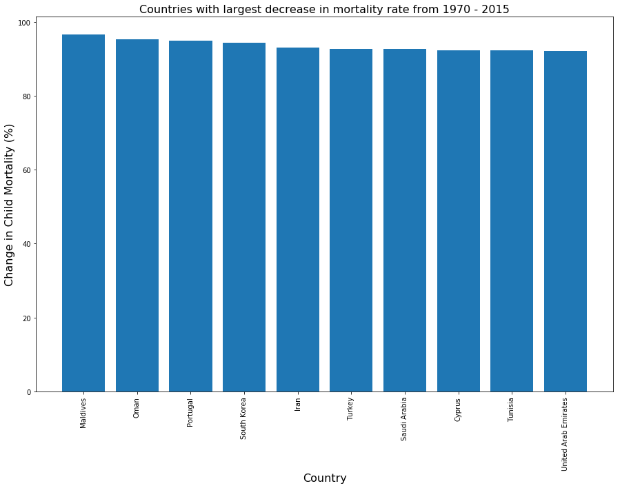

```python
#visualize the largest decrease in mortality rate
plt.figure(figsize=(15,10))
labels = M[M['level_rate'] == 'highest'].sort_values(by='rate')['country']
labels
plt.bar(labels, (M[M['level_rate'] == 'highest'].sort_values(by='rate')['rate']) *-1)
plt.xticks(rotation=90);
plt.xlabel('Country', fontsize=16)
plt.ylabel("Change in Child Mortality (%)", fontsize=16);
plt.title('Countries with largest decrease in mortality rate from 1970 - 2015', fontsize=16);
```

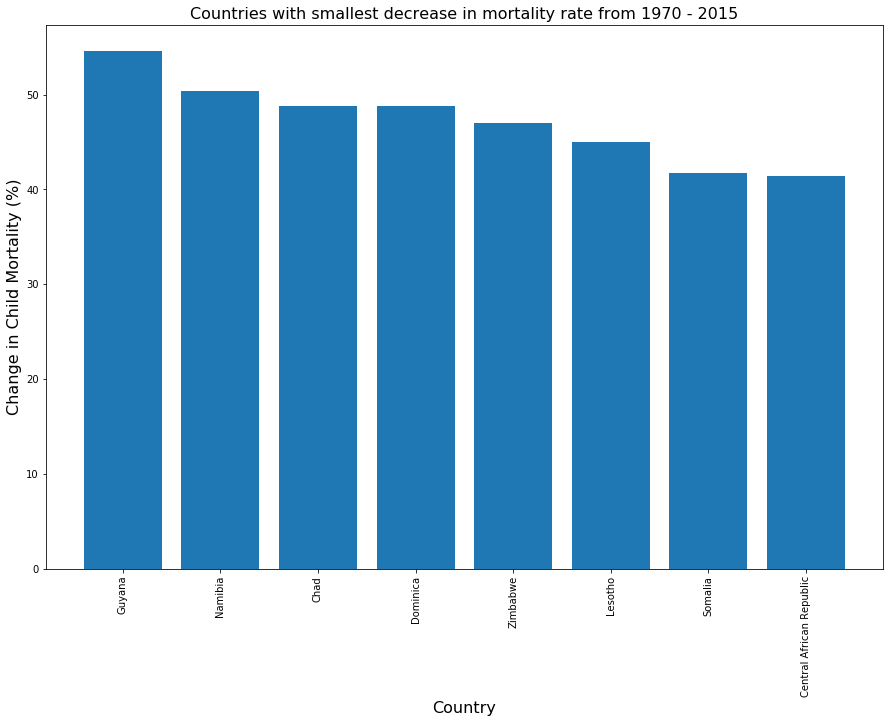

```python
#visualize the smallest decrease in mortality rate
plt.figure(figsize=(15,10))
labels = M[M['level_rate'] == 'low'].sort_values(by='rate')['country']
labels
plt.bar(labels, (M[M['level_rate'] == 'low'].sort_values(by='rate')['rate']) *-1)
plt.xticks(rotation=90);
plt.xlabel('Country', fontsize=16)
plt.ylabel("Change in Child Mortality (%)", fontsize=16);
plt.title('Countries with smallest decrease in mortality rate from 1970 - 2015', fontsize=16);
```

**C. Where has education rate of women increased the most since 1970? Where has it been stagnant?**

```python
school['rate'] = ((school['2015']-school['1970'])/school['1970']) *100
```

```python
sum = school['rate'].describe()
sum
```

```
count    187.000000
mean     229.370411
std      130.265639
min      34.821429
25%      119.052419
50%      189.171975
75%      319.602205
max      800.000000
Name: rate, dtype: float64
```

```python
#make bins

min1 = sum['min']
low = (min1 + sum['25%'])/2
low_med = sum['25%']
med = sum['50%']
med_high = sum['75%']
high = (med_high + sum['max'])/2
highest = sum['max']



bin_edges = [min1-0.001, low, low_med, med, med_high, high, highest+0.001]
bin_names = ['lowest', 'low', 'medium_low', 'medium', 'high', 'highest']
bin_edges
```

```
[34.82042857142858,
 76.93692396313364,
 119.05241935483869,
 189.17197452229297,
 319.6022046489336,
 559.8011023244668,
 800.001]
```

```python
#add bins to the school df
school['level_rate'] = pd.cut(school['rate'], bin_edges, labels=bin_names)

school['level_rate'].head(5)
```

```
0    high
1    medium_low
2    high
3    low
4    medium
Name: level_rate, dtype: category
Categories (6, object): [lowest < low < medium_low < medium < high < highest]
```

```python
#check to make sure every entry got a level
school['level_rate'].isnull().any().sum()
```

```
0
```

```python
#select lowest countries and select highest countries
school[school['level_rate'] == 'lowest']
```

|  | country | 1970 | 1971 | 1972 | 1973 | 1974 | 1975 | 1976 | 1977 | 1978 | 1979 | 1980 | 1981 | 1982 | 1983 | 1984 | 1985 | 1986 | 1987 | 1988 | 1989 | 1990 | 1991 | 1992 | 1993 | 1994 | 1995 | 1996 | 1997 | … |
| --- | --- | --- | --- | --- | --- | --- | --- | --- | --- | --- | --- | --- | --- | --- | --- | --- | --- | --- | --- | --- | --- | --- | --- | --- | --- | --- | --- | --- | --- | --- |
| 30 | Canada | 9.39 | 9.58 | 9.77 | 9.96 | 10.2 | 10.3 | 10.5 | 10.7 | 10.9 | 11.1 | 11.3 | 11.4 | 11.6 | 11.8 | 11.9 | 12.1 | 12.2 | 12.4 | 12.5 | 12.7 | 12.8 | 12.9 | 13.1 | 13.2 | 13.3 | 13.4 | 13.5 | 13.6 | … |
| 178 | United States | 11.20 | 11.40 | 11.50 | 11.60 | 11.8 | 11.9 | 12.0 | 12.1 | 12.2 | 12.3 | 12.4 | 12.5 | 12.6 | 12.7 | 12.8 | 12.9 | 13.0 | 13.0 | 13.1 | 13.2 | 13.2 | 13.3 | 13.3 | 13.3 | 13.4 | 13.4 | 13.4 | 13.5 | … |

```python
school[school['level_rate'] == 'highest']
```

|  | country | 1970 | 1971 | 1972 | 1973 | 1974 | 1975 | 1976 | 1977 | 1978 | 1979 | 1980 | 1981 | 1982 | 1983 | 1984 | 1985 | 1986 | 1987 | 1988 | 1989 | 1990 | 1991 | 1992 | 1993 | 1994 | 1995 | 1996 | 1997 | … |
| --- | --- | --- | --- | --- | --- | --- | --- | --- | --- | --- | --- | --- | --- | --- | --- | --- | --- | --- | --- | --- | --- | --- | --- | --- | --- | --- | --- | --- | --- | --- |
| 77 | Iran | 0.99 | 1.04 | 1.09 | 1.14 | 1.20 | 1.27 | 1.34 | 1.41 | 1.49 | 1.58 | 1.67 | 1.76 | 1.87 | 1.99 | 2.11 | 2.24 | 2.38 | 2.54 | 2.70 | 2.87 | 3.06 | 3.25 | 3.46 | 3.67 | 3.88 | 4.10 | 4.25 | 4.41 | … |
| 78 | Iraq | 1.02 | 1.07 | 1.12 | 1.18 | 1.24 | 1.30 | 1.37 | 1.45 | 1.52 | 1.61 | 1.69 | 1.79 | 1.89 | 1.99 | 2.11 | 2.23 | 2.35 | 2.49 | 2.63 | 2.78 | 2.94 | 3.11 | 3.28 | 3.46 | 3.65 | 3.83 | 3.97 | 4.12 | … |
| 171 | Tunisia | 0.83 | 0.87 | 0.91 | 0.96 | 1.01 | 1.06 | 1.12 | 1.18 | 1.24 | 1.31 | 1.38 | 1.46 | 1.54 | 1.63 | 1.73 | 1.83 | 1.94 | 2.06 | 2.19 | 2.33 | 2.49 | 2.65 | 2.83 | 3.02 | 3.22 | 3.44 | 3.60 | 3.76 | … |
| 184 | Yemen | 0.11 | 0.11 | 0.12 | 0.12 | 0.13 | 0.13 | 0.14 | 0.15 | 0.15 | 0.16 | 0.17 | 0.18 | 0.19 | 0.20 | 0.21 | 0.22 | 0.23 | 0.24 | 0.25 | 0.27 | 0.28 | 0.30 | 0.32 | 0.34 | 0.36 | 0.39 | 0.41 | 0.44 | … |

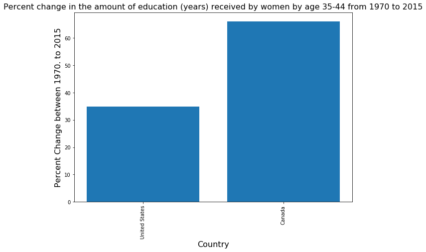

```python
#visualize the slowest growing
plt.figure(figsize=(10,7))
labels = school[school['level_rate'] == 'lowest'].sort_values(by='rate')['country']
labels
plt.bar(labels, school[school['level_rate'] == 'lowest'].sort_values(by='rate')['rate'])
plt.xticks(rotation=90);
plt.xlabel('Country', fontsize=16)
plt.ylabel("Percent Change between 1970. to 2015", fontsize=16);
plt.title("Percent change in the amount of education (years) received by women by age 35-44 from 1970 to 2015", fontsize=16);
```

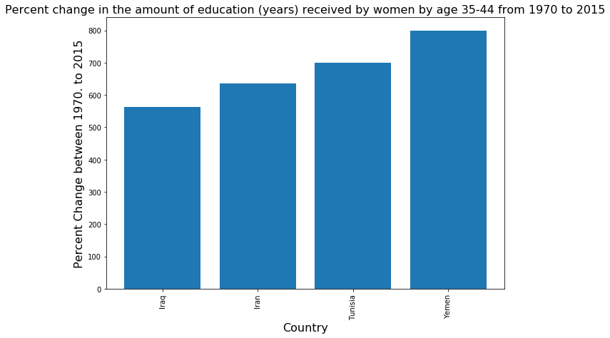

```python
##visualize the slowest growing
plt.figure(figsize=(10,7))
labels = school[school['level_rate'] == 'highest'].sort_values(by='rate')['country']
labels
plt.bar(labels, school[school['level_rate'] == 'highest'].sort_values(by='rate')['rate'])
plt.xticks(rotation=90);
plt.xlabel('Country', fontsize=16)
plt.ylabel("Percent Change between 1970. to 2015", fontsize=16);
plt.title("Percent change in the amount of education (years) received by women by age 35-44 from 1970 to 2015", fontsize=16);
```

### Research Question 3: What is the child mortality rate like in countries with highly educated women compared to those with uneducated women?

> Do wealthier countries have more highly educated women?  
> Do wealthier countries have lower child mortality?  
> Do highly educated women have healthier babies/children?

```python
# plot wealth vs. female eduction
# plot wealth vs child mortality
#plot female eduction vs child mortality (where size of the pt indicates GDP of the country)
```

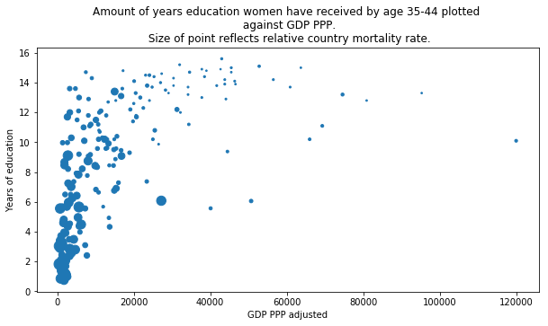

```python
plt.figure(figsize=(10,5))
plt.scatter(inc['2015'], school['2015'], s=M['2015']*1.15)
plt.xlabel('GDP PPP adjusted')
plt.ylabel("Years of education")
plt.title('Amount of years education women have received by age 35-44 plotted \n against GDP PPP.\n Size of point reflects relative country mortality rate.');
```

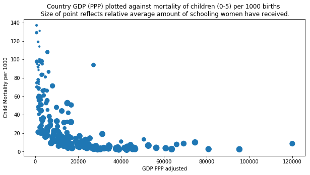

```python
plt.figure(figsize=(10,5))
plt.scatter(inc['2015'], M['2015'], s = school['2015']*10)
plt.xlabel('GDP PPP adjusted')
plt.ylabel('Child Mortality per 1000')
plt.title('Country GDP (PPP) plotted against mortality of children (0-5) per 1000 births \n Size of point reflects relative average amount of schooling women have received.');
```

```python
#lets look at poor countries only
poor_countries = inc[inc['levels2015']== "lowest"]['country'].tolist()
poor_countries
```

```
['Afghanistan',
 'Burkina Faso',
 'Burundi',
 'Central African Republic',
 'Comoros',
 'Congo, Dem. Rep.',
 'Eritrea',
 'Ethiopia',
 'Gambia',
 'Guinea',
 'Guinea-Bissau',
 'Haiti',
 'Kiribati',
 'Liberia',
 'Madagascar',
 'Malawi',
 'Mali',
 'Mozambique',
 'Niger',
 'North Korea',
 'Rwanda',
 'Sierra Leone',
 'Somalia',
 'South Sudan',
 'Togo',
 'Uganda',
 'Zimbabwe']
```

```python
school_poor = school[school['country'].isin(poor_countries)]
M_poor = M[M['country'].isin(poor_countries)]
```

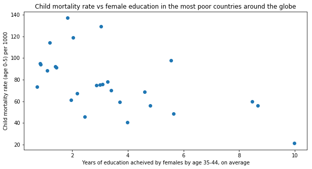

```python
plt.figure(figsize=(10,5))
plt.scatter(school_poor['2015'], M_poor['2015'])
plt.xlabel('Years of education acheived by females by age 35-44, on average')
plt.ylabel('Child mortality rate (age 0-5) per 1000')
plt.title('Child mortality rate vs female education in the most poor countries around the globe');
```

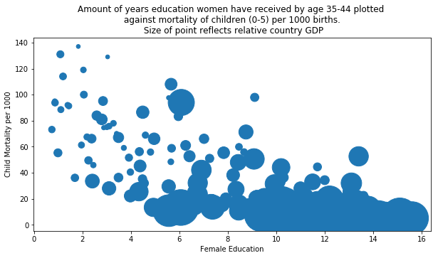

```python
plt.figure(figsize=(10,5))
plt.scatter(school['2015'], M['2015'], s = inc['2015']*0.05)
plt.xlabel('Female Education')
plt.ylabel('Child Mortality per 1000')
plt.title('Amount of years education women have received by age 35-44 plotted \n against mortality of children (0-5) per 1000 births. \n Size of point reflects relative country GDP');
```

```python
# Continue to explore the data to address your additional research
#   questions. Add more headers as needed if you have more questions to
#   investigate.
```

## Conclusions

For this project I explored the Gapminder datasets. I specifically chose to explore GPD (PPP), child mortality rate, and female education levels around the globe.

Female education levels around the globe were generally related to GDP but the relationsip was not a strong as I would have hypothesized. For example, average number of years educated could be the same for countries that have a GDP PPP of only 20,000 as countries with GDP closer to 100,000. After reading more about GDP PPP, it seems that it may not be the most accurate description of personal income. Also, the primary export of many countries with high GDP is oil and the wealth may not be distributed evenly between men and women.

Another conclusion that I made was that, not surprisingly, children in wealthier countries fare better. But what is notable is that female education may also strongly predict child mortality rates. For example, among poor countries, countries with more educated women have healthier babies and children (lower child mortality).